# **First experimental evidence for active farming in ambrosia beetles and strong heredity of garden microbiomes** - Bacterial Analysis

Janina M.C. Diehl

08.07.2022

# **Data Preparation**

load required packages

```r
library(lme4)
library(permute)
library(lattice)
library(vegan)
library(phyloseq)
library(ggplot2)
library(dplyr)
library(scales)
library(grid)
library(DHARMa)
library(ggeffects)
library(glmmTMB)
library(lmerTest)
library(emmeans)
library(sjPlot)
library(fitdistrplus)
library(GLMMadaptive)
library(microbiome)
library(microbiomeutilities)
library(knitr)
library(ggpubr)
library(doBy)
library(performance)
library(see)
library(patchwork)
library(pairwiseAdonis)
library(cowplot)
library(multcomp)
library(car)
library(forcats)
library(ggrepel)
library(tidyverse)
```

### loading the data files for bacteria

```r
data16S <- otu_table(read.table("16S_Rem_zotu_table.txt",sep="\t", header=T, row.names=1, check.names = F), taxa_are_rows=T)
tax16S <- tax_table(as.matrix(read.table("16S_Rem_zotus.tax.txt", sep="\t", header=T, row.names=1, fill=T)))
datasample16S  <- sample_data(read.table("16S_map_removal.txt", sep="\t", header=T, row.names=1))
```

### merge data into phyloseq object

```r
(all16S <- merge_phyloseq(data16S, tax16S, datasample16S))
```

```
## phyloseq-class experiment-level object
## otu_table()   OTU Table:         [ 365 taxa and 57 samples ]
## sample_data() Sample Data:       [ 57 samples by 16 sample variables ]
## tax_table()   Taxonomy Table:    [ 365 taxa by 8 taxonomic ranks ]
```

### copy taxonomic classification in tax_table collumns with gaps and add "_spc"

```r
dataset.16S =  subset_taxa(all16S, (Domain == "d:Bacteria"))
tax_table(dataset.16S)[tax_table(dataset.16S)[,"Phylum"]=="","Phylum"]<-paste(tax_table(dataset.16S)[tax_table(dataset.16S)[,"Phylum"]=="","Domain"],"_spc",sep="")
tax_table(dataset.16S)[tax_table(dataset.16S)[,"Class"]=="","Class"]<-paste(tax_table(dataset.16S)[tax_table(dataset.16S)[,"Class"]=="","Phylum"],"_spc",sep="")
tax_table(dataset.16S)[tax_table(dataset.16S)[,"Order"]=="","Order"]<-paste(tax_table(dataset.16S)[tax_table(dataset.16S)[,"Order"]=="","Class"],"_spc",sep="")
tax_table(dataset.16S)[tax_table(dataset.16S)[,"Family"]=="","Family"]<-paste(tax_table(dataset.16S)[tax_table(dataset.16S)[,"Family"]=="","Order"],"_spc",sep="")
tax_table(dataset.16S)[tax_table(dataset.16S)[,"Genus"]=="","Genus"]<-paste(tax_table(dataset.16S)[tax_table(dataset.16S)[,"Genus"]=="","Family"],"_spc",sep="")
tax_table(dataset.16S)[tax_table(dataset.16S)[,"Species"]=="","Species"]<-paste(tax_table(dataset.16S)[tax_table(dataset.16S)[,"Species"]=="","Genus"],"_spc",sep="")
```

### start filtering out all ZOTUs that were only assigned to Domain (Bacteria and Archaea), as well as Chloroplasts

```r
dataset.16S.ordi =  subset_taxa(dataset.16S, (Domain == "d:Bacteria" | Domain =="d:Archaea"))
dataset.16S.ordi =  subset_taxa(dataset.16S.ordi, Phylum != "d:Bacteria_spc")
dataset.16S.ordi =  subset_taxa(dataset.16S.ordi, Phylum != "d:Archaea_spc")
dataset.16S.ordi =  subset_taxa(dataset.16S.ordi, Class != "c:Chloroplast")
```

controlled for most abundant ZOTUS in the dataset with Bacteria sp. and Archaea sp. still included in https://blast.ncbi.nlm.nih.gov/Blast.cgi?PROGRAM=blastn&PAGE_TYPE=BlastSearch&LINK_LOC=blasthome ==> mitochondrial DNA

Zotu1 –> Leptographium (Ophiostomataceae) max/total score: 340, Query Cover: 100%, e-value: 2e-89, Per. Ident 93.81%

Zotu3 –> Leptographium (Ophiostomataceae) max/total score: 274, Query Cover: 100%, e-value: 2e-69, Per. Ident 88.60%

Zotu4 –> Ophiostoma (Query Cover : 100%, Per. Ident: 89.96%) or Grosmannia (Query Cover: 93%, Per. Ident: 91.51%)

Zotu6 –> Hydropisphaera (Trichoderma, Fusarium close) max/total score: 316, Query Cover: 100%, e-value: 3e-82, Per. Ident 92.44%

Zotu7 –> Wolbachia rRNA max/total score: 468, Query Cover: 100%, e-value: 8e-128, Per. Ident 100%

Zotu11 –> Clematis sp. or Ranunculus sp. max/total score: 464, Query Cover: 100%, e-value: 1e-126, Per. Ident 100%

Zotu12 –> Cannabis max/total score: 464, Query Cover: 100%, e-value: 1e-126, Per. Ident 100%

note: we need to exclude these Zotus since they are not bacterial species (except Wolbachia), keep this in mind for the fungal analysis

### check all the columns for patterns ranging from [a-z] joined by __ like this [a-z]__ and substitute it with "" i.e. nothing.

```r
tax_table(dataset.16S.ordi)[, colnames(tax_table(dataset.16S.ordi))] <- gsub(tax_table(dataset.16S.ordi)[, colnames(tax_table(dataset.16S.ordi))],     pattern = "[a-z]:", replacement = "")
tax_table(dataset.16S.ordi)[, colnames(tax_table(dataset.16S.ordi))] <- gsub(tax_table(dataset.16S.ordi)[, colnames(tax_table(dataset.16S.ordi))],     pattern = "_spc_spc_spc", replacement = "_spc")
tax_table(dataset.16S.ordi)[, colnames(tax_table(dataset.16S.ordi))] <- gsub(tax_table(dataset.16S.ordi)[, colnames(tax_table(dataset.16S.ordi))],     pattern = "_spc_spc", replacement = "_spc")
tax_table(dataset.16S.ordi)[, colnames(tax_table(dataset.16S.ordi))] <- gsub(tax_table(dataset.16S.ordi)[, colnames(tax_table(dataset.16S.ordi))],     pattern = "-", replacement = "_")
tax_table(dataset.16S.ordi) <- tax_table(dataset.16S.ordi)[,2:8]
```

### Format the phyloseq object to add the best taxonomy in phyloseq object (tax_table and otu_table).

```r
dataset.16S.ordi <- format_to_besthit(dataset.16S.ordi)
taxa_names(dataset.16S.ordi)[1:5]
```

```
## [1] "Zotu2:Pseudoxanthomonas_spadix" "Zotu48:Microbacterium_spc"
## [3] "Zotu21:Microbacterium_pygmaeum" "Zotu66:Sphingobacterium_spc"
## [5] "Zotu260:Gp3_spc"
```

#### check the table without Bacteria and Archaea sp. for total reads per sample

```r
colSums(otu_table(dataset.16S.ordi))
```

```
##    B0-19a    B0-19b    B0-22a    B0-22b     B0-24     B0-27    B10-01    B10-06
##     17492     17718      1365      2348      1424       803       659       226
##   B10-09a   B10-09b    B10-18    B10-24   B10-25a   B10-25b   B10-26a   B15-01a
##       133       132       175       221        98       202       261       359
##   B15-01b    B15-06   B15-07a   B15-07b    B15-11    B15-20    B15-24   B15-25a
##       306      3589      3152      1184      3184      4624      1181       281
##   B15-25b   B16-01a    B16-04   B16-31a   B16-31b   B20-04a   B20-08a   B20-08b
##      1156     24582     24435     36064     20380     28703      7581     14344
##    B20-11    B23-21   B23-23a   B24-02a   B24-26a   B24-26b   B24-28a    B24-29
##     22250       312       472     21494     44940      9135     14354       174
##   B36-14a   B36-14b    B36-30   B36-31a    B36-32    B39-15    B39-16   B39-17a
##     12948     10866     11903     24530     24335     26401     26823     29121
##    B46-03     B7-07    B7-08a   medium1   medium2 negative1 negative2 standard1
##     15551     19370     12785      3672      6445      2584      3926     10263
## standard2
##      9062
```

there are now samples that lost a lot of reads due to this filtering step –> not good for later analysis, some samples might get excluded ahead to secure robustness

## check controls from dataset: only ten most abundant ZOTUs are picked for visualisation

```r
neg.controls<-subset_samples(dataset.16S.ordi, Treatment=="medium" | Treatment=="negative")
sample_names(neg.controls)
```

```
## [1] "medium1"   "medium2"   "negative1" "negative2"
```

```r
neg <- prune_taxa(taxa_sums(neg.controls) > 0, neg.controls)
```

**visualisation of negative controls**

```r
filtaxa <- names (sort(rowSums(otu_table(neg)) ,decreasing=T))[1:10]
tax_table(dataset.16S.ordi)[filtaxa]
```

```
## Taxonomy Table:     [10 taxa by 8 taxonomic ranks]:
##                                         Domain     Phylum
## Zotu19:Streptomyces_xanthophaeus        "Bacteria" "Actinobacteria"
## Zotu20:Pseudomonas_brenneri             "Bacteria" "Proteobacteria"
## Zotu28:Halomonadaceae_spc               "Bacteria" "Proteobacteria"
## Zotu36:Pelomonas_aquatica               "Bacteria" "Proteobacteria"
## Zotu17:Staphylococcus_aureus            "Bacteria" "Firmicutes"
## Zotu33:Sediminibacterium_spc            "Bacteria" "Bacteroidetes"
## Zotu42:Halomonas_desiderata             "Bacteria" "Proteobacteria"
## Zotu39:Acinetobacter_indicus            "Bacteria" "Proteobacteria"
## Zotu41:Lactobacillus_spc                "Bacteria" "Firmicutes"
## Zotu40:Undibacterium_oligocarboniphilum "Bacteria" "Proteobacteria"
##                                         Class
## Zotu19:Streptomyces_xanthophaeus        "Actinobacteria"
## Zotu20:Pseudomonas_brenneri             "Gammaproteobacteria"
## Zotu28:Halomonadaceae_spc               "Gammaproteobacteria"
## Zotu36:Pelomonas_aquatica               "Betaproteobacteria"
## Zotu17:Staphylococcus_aureus            "Bacilli"
## Zotu33:Sediminibacterium_spc            "Sphingobacteriia"
## Zotu42:Halomonas_desiderata             "Gammaproteobacteria"
## Zotu39:Acinetobacter_indicus            "Gammaproteobacteria"
## Zotu41:Lactobacillus_spc                "Bacilli"
## Zotu40:Undibacterium_oligocarboniphilum "Betaproteobacteria"
##                                         Order
## Zotu19:Streptomyces_xanthophaeus        "Actinomycetales"
## Zotu20:Pseudomonas_brenneri             "Pseudomonadales"
## Zotu28:Halomonadaceae_spc               "Oceanospirillales"
## Zotu36:Pelomonas_aquatica               "Burkholderiales"
## Zotu17:Staphylococcus_aureus            "Bacillales"
## Zotu33:Sediminibacterium_spc            "Sphingobacteriales"
## Zotu42:Halomonas_desiderata             "Oceanospirillales"
## Zotu39:Acinetobacter_indicus            "Pseudomonadales"
## Zotu41:Lactobacillus_spc                "Lactobacillales"
## Zotu40:Undibacterium_oligocarboniphilum "Burkholderiales"
##                                         Family
## Zotu19:Streptomyces_xanthophaeus        "Streptomycetaceae"
## Zotu20:Pseudomonas_brenneri             "Pseudomonadaceae"
## Zotu28:Halomonadaceae_spc               "Halomonadaceae"
## Zotu36:Pelomonas_aquatica               "Comamonadaceae"
## Zotu17:Staphylococcus_aureus            "Staphylococcaceae"
```

[output cut: 23 more lines]

```
## Zotu42:Halomonas_desiderata             "Halomonas_desiderata"
## Zotu39:Acinetobacter_indicus            "Acinetobacter_indicus"
## Zotu41:Lactobacillus_spc                "Lactobacillus_spc"
## Zotu40:Undibacterium_oligocarboniphilum "Undibacterium_oligocarboniphilum"
##                                         best_hit
## Zotu19:Streptomyces_xanthophaeus        "Zotu19:Streptomyces_xanthophaeus"
## Zotu20:Pseudomonas_brenneri             "Zotu20:Pseudomonas_brenneri"
## Zotu28:Halomonadaceae_spc               "Zotu28:Halomonadaceae_spc"
## Zotu36:Pelomonas_aquatica               "Zotu36:Pelomonas_aquatica"
## Zotu17:Staphylococcus_aureus            "Zotu17:Staphylococcus_aureus"
## Zotu33:Sediminibacterium_spc            "Zotu33:Sediminibacterium_spc"
## Zotu42:Halomonas_desiderata             "Zotu42:Halomonas_desiderata"
## Zotu39:Acinetobacter_indicus            "Zotu39:Acinetobacter_indicus"
## Zotu41:Lactobacillus_spc                "Zotu41:Lactobacillus_spc"
## Zotu40:Undibacterium_oligocarboniphilum "Zotu40:Undibacterium_oligocarboniphilum"
```

```r
round(otu_table(dataset.16S.ordi)[filtaxa], digits = 4)
```

```
## OTU Table:          [10 taxa and 57 samples]
##                      taxa are rows
##                                         B0-19a B0-19b B0-22a B0-22b B0-24 B0-27
## Zotu19:Streptomyces_xanthophaeus            29      0      7      0     2     0
## Zotu20:Pseudomonas_brenneri                  8      0     46      0     0     1
## Zotu28:Halomonadaceae_spc                   10      1     23      0     0     0
## Zotu36:Pelomonas_aquatica                   10      0     18      2     4     1
## Zotu17:Staphylococcus_aureus                 7      0      7      4     2     0
## Zotu33:Sediminibacterium_spc                12      0     10      0     0     0
## Zotu42:Halomonas_desiderata                  6      0     12      0     0     0
## Zotu39:Acinetobacter_indicus                 2      0     15      0     2     0
## Zotu41:Lactobacillus_spc                     0      0     16      0     1     0
## Zotu40:Undibacterium_oligocarboniphilum      3      0      7      0     0     0
##                                         B10-01 B10-06 B10-09a B10-09b B10-18
## Zotu19:Streptomyces_xanthophaeus            71      0       0       1      4
## Zotu20:Pseudomonas_brenneri                 68      0       0       4      2
## Zotu28:Halomonadaceae_spc                   25      0       0       0      1
## Zotu36:Pelomonas_aquatica                   12      2       0       0      2
## Zotu17:Staphylococcus_aureus                14      1       0       0      1
## Zotu33:Sediminibacterium_spc                16      0       0       0      0
## Zotu42:Halomonas_desiderata                  9      0       0       0      3
## Zotu39:Acinetobacter_indicus                 4      0       0       1      0
## Zotu41:Lactobacillus_spc                     8      0       0       0      0
## Zotu40:Undibacterium_oligocarboniphilum     14      1       0       0      0
##                                         B10-24 B10-25a B10-25b B10-26a B15-01a
## Zotu19:Streptomyces_xanthophaeus             0       3       1       1       1
## Zotu20:Pseudomonas_brenneri                  0       2       1       0       5
## Zotu28:Halomonadaceae_spc                    0       0       0       0       1
## Zotu36:Pelomonas_aquatica                    3       0       1       2      10
## Zotu17:Staphylococcus_aureus                 3      10       6       3      12
## Zotu33:Sediminibacterium_spc                10       0       0       1       0
## Zotu42:Halomonas_desiderata                  0       0       2       0       0
## Zotu39:Acinetobacter_indicus                 0       0       0       0       0
## Zotu41:Lactobacillus_spc                     0       1       0       0       1
## Zotu40:Undibacterium_oligocarboniphilum      5       0       0       0       0
##                                         B15-01b B15-06 B15-07a B15-07b B15-11
## Zotu19:Streptomyces_xanthophaeus              0      0       0       0      1
## Zotu20:Pseudomonas_brenneri                   9      0       0       0      1
## Zotu28:Halomonadaceae_spc                     0      0       0       2      0
## Zotu36:Pelomonas_aquatica                     4      2       3       0      1
```

[output cut: 79 more lines]

```
## Zotu42:Halomonas_desiderata                  60     147        78       116
## Zotu39:Acinetobacter_indicus                 86     107        68       136
## Zotu41:Lactobacillus_spc                     50     146        60        94
## Zotu40:Undibacterium_oligocarboniphilum      57     143        35        76
##                                         standard1 standard2
## Zotu19:Streptomyces_xanthophaeus                0         0
## Zotu20:Pseudomonas_brenneri                     0         0
## Zotu28:Halomonadaceae_spc                       1         0
## Zotu36:Pelomonas_aquatica                       1         0
## Zotu17:Staphylococcus_aureus                 1104       962
## Zotu33:Sediminibacterium_spc                    0         0
## Zotu42:Halomonas_desiderata                     0         0
## Zotu39:Acinetobacter_indicus                    0         0
## Zotu41:Lactobacillus_spc                        0         0
## Zotu40:Undibacterium_oligocarboniphilum         0         0
```

only very low read numbers of most abundant ZOTUS in our samples we let ZOTUS from neg. controls in the samples and choose they way of low abundance filtering/decontam!

**check for ten most abundant ZOTUs in pos.controls**

```r
pos.controls<-subset_samples(dataset.16S.ordi, Treatment=="standard")
sample_names(pos.controls)
```

```
## [1] "standard1" "standard2"
```

```r
filtaxa <- names (sort(rowSums(otu_table(pos.controls)) ,decreasing=T))[1:10]
tax_table(dataset.16S.ordi)[filtaxa]
```

```
## Taxonomy Table:     [10 taxa by 8 taxonomic ranks]:
##                                Domain     Phylum
## Zotu15:Salmonella_enterica     "Bacteria" "Proteobacteria"
## Zotu14:Escherichia_coli        "Bacteria" "Proteobacteria"
## Zotu18:Enterococcus_faecalis   "Bacteria" "Firmicutes"
## Zotu17:Staphylococcus_aureus   "Bacteria" "Firmicutes"
## Zotu25:Bacillus_subtilis       "Bacteria" "Firmicutes"
## Zotu27:Lactobacillus_fermentum "Bacteria" "Firmicutes"
## Zotu23:Pseudomonas_aeruginosa  "Bacteria" "Proteobacteria"
## Zotu29:Listeria_monocytogenes  "Bacteria" "Firmicutes"
## Zotu52:Enterobacteriaceae_spc  "Bacteria" "Proteobacteria"
## Zotu147:Enterobacteriaceae_spc "Bacteria" "Proteobacteria"
##                                Class                 Order
## Zotu15:Salmonella_enterica     "Gammaproteobacteria" "Enterobacteriales"
## Zotu14:Escherichia_coli        "Gammaproteobacteria" "Enterobacteriales"
## Zotu18:Enterococcus_faecalis   "Bacilli"             "Lactobacillales"
## Zotu17:Staphylococcus_aureus   "Bacilli"             "Bacillales"
## Zotu25:Bacillus_subtilis       "Bacilli"             "Bacillales"
## Zotu27:Lactobacillus_fermentum "Bacilli"             "Lactobacillales"
## Zotu23:Pseudomonas_aeruginosa  "Gammaproteobacteria" "Pseudomonadales"
## Zotu29:Listeria_monocytogenes  "Bacilli"             "Bacillales"
## Zotu52:Enterobacteriaceae_spc  "Gammaproteobacteria" "Enterobacteriales"
## Zotu147:Enterobacteriaceae_spc "Gammaproteobacteria" "Enterobacteriales"
##                                Family               Genus
## Zotu15:Salmonella_enterica     "Enterobacteriaceae" "Salmonella"
## Zotu14:Escherichia_coli        "Enterobacteriaceae" "Escherichia"
## Zotu18:Enterococcus_faecalis   "Enterococcaceae"    "Enterococcus"
## Zotu17:Staphylococcus_aureus   "Staphylococcaceae"  "Staphylococcus"
## Zotu25:Bacillus_subtilis       "Bacillaceae_1"      "Bacillus"
## Zotu27:Lactobacillus_fermentum "Lactobacillaceae"   "Lactobacillus"
## Zotu23:Pseudomonas_aeruginosa  "Pseudomonadaceae"   "Pseudomonas"
## Zotu29:Listeria_monocytogenes  "Listeriaceae"       "Listeria"
## Zotu52:Enterobacteriaceae_spc  "Enterobacteriaceae" "Enterobacteriaceae_spc"
## Zotu147:Enterobacteriaceae_spc "Enterobacteriaceae" "Enterobacteriaceae_spc"
##                                Species
## Zotu15:Salmonella_enterica     "Salmonella_enterica"
## Zotu14:Escherichia_coli        "Escherichia_coli"
## Zotu18:Enterococcus_faecalis   "Enterococcus_faecalis"
## Zotu17:Staphylococcus_aureus   "Staphylococcus_aureus"
## Zotu25:Bacillus_subtilis       "Bacillus_subtilis"
## Zotu27:Lactobacillus_fermentum "Lactobacillus_fermentum"
## Zotu23:Pseudomonas_aeruginosa  "Pseudomonas_aeruginosa"
## Zotu29:Listeria_monocytogenes  "Listeria_monocytogenes"
## Zotu52:Enterobacteriaceae_spc  "Enterobacteriaceae_spc"
## Zotu147:Enterobacteriaceae_spc "Enterobacteriaceae_spc"
##                                best_hit
## Zotu15:Salmonella_enterica     "Zotu15:Salmonella_enterica"
## Zotu14:Escherichia_coli        "Zotu14:Escherichia_coli"
## Zotu18:Enterococcus_faecalis   "Zotu18:Enterococcus_faecalis"
## Zotu17:Staphylococcus_aureus   "Zotu17:Staphylococcus_aureus"
## Zotu25:Bacillus_subtilis       "Zotu25:Bacillus_subtilis"
## Zotu27:Lactobacillus_fermentum "Zotu27:Lactobacillus_fermentum"
## Zotu23:Pseudomonas_aeruginosa  "Zotu23:Pseudomonas_aeruginosa"
## Zotu29:Listeria_monocytogenes  "Zotu29:Listeria_monocytogenes"
## Zotu52:Enterobacteriaceae_spc  "Zotu52:Enterobacteriaceae_spc"
## Zotu147:Enterobacteriaceae_spc "Zotu147:Enterobacteriaceae_spc"
```

```r
round(otu_table(dataset.16S.ordi)[filtaxa], digits = 4)
```

```
## OTU Table:          [10 taxa and 57 samples]
##                      taxa are rows
##                                B0-19a B0-19b B0-22a B0-22b B0-24 B0-27 B10-01
## Zotu15:Salmonella_enterica          3      0      0      0    10     0      1
## Zotu14:Escherichia_coli             2      0      1      0     0     3      0
## Zotu18:Enterococcus_faecalis        0      0      0      0     0     0      0
## Zotu17:Staphylococcus_aureus        7      0      7      4     2     0     14
## Zotu25:Bacillus_subtilis            0      0      0      0     0     0      0
## Zotu27:Lactobacillus_fermentum      1      0      0      0     0     0      0
## Zotu23:Pseudomonas_aeruginosa       1      0      2      0     0     0      3
## Zotu29:Listeria_monocytogenes       0      0      0      0     0     0      0
## Zotu52:Enterobacteriaceae_spc       0      0      0      0     0     0      0
## Zotu147:Enterobacteriaceae_spc      0      0      0      0     0     0      0
##                                B10-06 B10-09a B10-09b B10-18 B10-24 B10-25a
## Zotu15:Salmonella_enterica          1       4       1      0      2       0
## Zotu14:Escherichia_coli             0       1       0      0      0       1
## Zotu18:Enterococcus_faecalis        0       0       0      0      0       0
## Zotu17:Staphylococcus_aureus        1       0       0      1      3      10
## Zotu25:Bacillus_subtilis            0       0       0      0      2       0
## Zotu27:Lactobacillus_fermentum      0       0       0      0      0       0
## Zotu23:Pseudomonas_aeruginosa       0       0       3      0      0       1
## Zotu29:Listeria_monocytogenes       0       0       1      0      0       0
## Zotu52:Enterobacteriaceae_spc       0       0       0      0      0       0
## Zotu147:Enterobacteriaceae_spc      0       0       0      0      0       0
##                                B10-25b B10-26a B15-01a B15-01b B15-06 B15-07a
## Zotu15:Salmonella_enterica           0       1       0       1      1       1
## Zotu14:Escherichia_coli              0       0       0       0      0       0
## Zotu18:Enterococcus_faecalis         0       0       0       0      0       0
## Zotu17:Staphylococcus_aureus         6       3      12       0      0       2
## Zotu25:Bacillus_subtilis             0       3       0       0      0       0
## Zotu27:Lactobacillus_fermentum       0       0       0       0      0       0
## Zotu23:Pseudomonas_aeruginosa        0       0       0       0      0       0
## Zotu29:Listeria_monocytogenes        0       0       0       0      0       0
## Zotu52:Enterobacteriaceae_spc        0       0       0       0      0       0
## Zotu147:Enterobacteriaceae_spc       0       0       0       0      0       0
##                                B15-07b B15-11 B15-20 B15-24 B15-25a B15-25b
## Zotu15:Salmonella_enterica           0      1      1      0       1       1
## Zotu14:Escherichia_coli              0      1      0      0       0       0
## Zotu18:Enterococcus_faecalis         0      0      0      0       0       0
## Zotu17:Staphylococcus_aureus         1      4      8      0       2       0
```

[output cut: 57 more lines]

```
## Zotu23:Pseudomonas_aeruginosa      0      0      18      60        24        19
## Zotu29:Listeria_monocytogenes      0      0       0       0         2         0
## Zotu52:Enterobacteriaceae_spc      0      0       0       0         0         0
## Zotu147:Enterobacteriaceae_spc     0      0       0       0         0         0
##                                standard1 standard2
## Zotu15:Salmonella_enterica          2527      2083
## Zotu14:Escherichia_coli             2414      2130
## Zotu18:Enterococcus_faecalis        1138      1035
## Zotu17:Staphylococcus_aureus        1104       962
## Zotu25:Bacillus_subtilis             664       598
## Zotu27:Lactobacillus_fermentum       615       550
## Zotu23:Pseudomonas_aeruginosa        599       507
## Zotu29:Listeria_monocytogenes        443       399
## Zotu52:Enterobacteriaceae_spc        183       165
## Zotu147:Enterobacteriaceae_spc       103       109
```

==> except Zotu 52 + 147 all Species were supposed to be present in Zymo Standard Community, but those two are not fully identified

#### define color bar for the next plots

```r
Family_colors <- c("#CBD588", "burlywood1","#DA5724", "#508578", "#CD9BCD", "orange"  , "#AD6F3B",  "#673770","#0c6985","#D14285", "#652926", "#C84248", "lightgreen", "blueviolet", "darkgreen", "#8569D5", "#5E738F","#D1A33D", "#8A7C64", "#599861", "#541f03",  "#b64609", "#f4671a", "#e3a380", "#d22323", "#a19b10", "#eae34e", "#6b6935", "#fff400", "#c5c398", "#5f833c" , "#9ac570", "#75d816", "#c2ff89", "#377200", "#3dc97f", "#08eccf", "#119c8b", "#77b2aa", "#3be3b4", "#237c96", "#21b2dd", "#6abed6", "#a5daea", "#0c6985", "#0c1485", "#404cf6", "#6c72c3", "#9ea2d6", "#9767c9", "#501094", "#b11dc3", "#e47ff0", "#e51bbe", "#f01c7c", "#ec84b3", "#f60838","burlywood1", "peachpuff4", "grey87", "bisque", "gold", "lightgreen", "forestgreen")
```

### plot controls

prepare data for plotting

```r
negs <- subset_samples(dataset.16S.ordi, Treatment == "negative" | Treatment == "medium")

pos <- subset_samples(dataset.16S.ordi, Treatment == "standard")

Bacteria_Genus.pos <- pos %>%
  tax_glom(taxrank = "Genus") %>%
  transform_sample_counts(function(x) {x/sum(x)} ) %>%
  psmelt() %>%
  arrange(Genus)

Bacteria_Genus.pos$Genus<-as.character(Bacteria_Genus.pos$Genus)
Bacteria_Genus.pos$Genus[Bacteria_Genus.pos$Abundance<0.01]<-"Others"
Bacteria_Genus.pos$Class<-as.character(Bacteria_Genus.pos$Class)
Bacteria_Genus.pos$Class[Bacteria_Genus.pos$Abundance<0.01]<-"Others"

Bacteria_Genus.neg <- negs %>%
  tax_glom(taxrank = "Genus") %>%
  transform_sample_counts(function(x) {x/sum(x)} ) %>%
  psmelt() %>%
  arrange(Genus)

Bacteria_Genus.neg$Genus<-as.character(Bacteria_Genus.neg$Genus)
Bacteria_Genus.neg$Genus[Bacteria_Genus.neg$Abundance<0.02]<-"Others"
Bacteria_Genus.neg$Class<-as.character(Bacteria_Genus.neg$Class)
Bacteria_Genus.neg$Class[Bacteria_Genus.neg$Abundance<0.02]<-"Others"
```

plot standard controls prae decontam

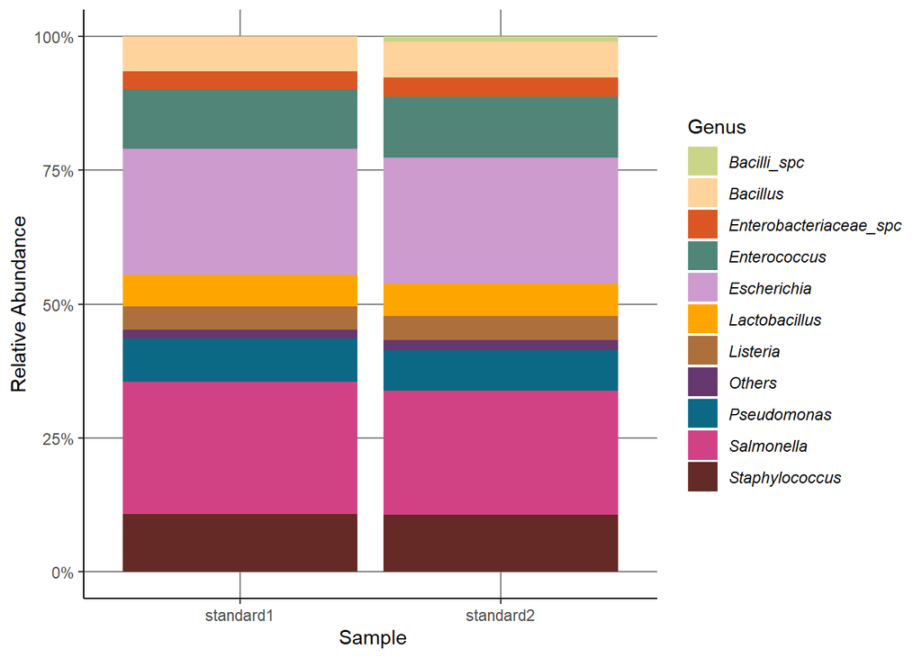

```r
Bacteria_Genus.pos_plot <-ggplot(Bacteria_Genus.pos, aes(x = Sample, y = Abundance, fill = Genus)) +   geom_bar(stat = "identity", position="fill") +
  scale_fill_manual(values = Family_colors, name = "Genus")

g1<-Bacteria_Genus.pos_plot +
  theme(plot.title = element_text(size = 20, face = "bold")) +
  theme(text = element_text(size=20, face = "bold"))+
  theme(axis.text.x=element_text(size = rel(0.5)))+
  theme(legend.title = element_text(size = 20), legend.text = element_text(size = 14))+
  theme_classic()+           #gets rid of background
  theme(panel.grid.major = element_line(colour = "grey50"))+
  labs(x=" Sample", y="Relative Abundance")+
  scale_y_continuous(labels=percent_format())+
  theme(legend.text = element_text(face = "italic"))

g1
```

negative controls prae decontam

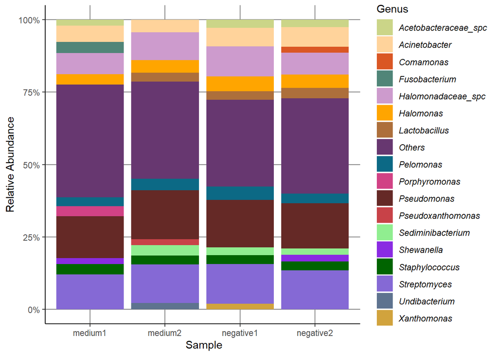

```r
Bacteria_Genus.neg_plot <-ggplot(Bacteria_Genus.neg, aes(x = Sample, y = Abundance, fill = Genus)) +
  geom_bar(stat = "identity", position="fill") +
  scale_fill_manual(values = Family_colors, name = "Genus")

g2<-Bacteria_Genus.neg_plot +
  theme(plot.title = element_text(size = 20, face = "bold")) +
  theme(text = element_text(size=20, face = "bold"))+
  theme(axis.text.x=element_text(size = rel(0.5)))+
  theme(legend.title = element_text(size = 20), legend.text = element_text(size = 14))+
  theme_classic()+           #gets rid of background
  theme(panel.grid.major = element_line(colour = "grey50"))+
  labs(x=" Sample", y="Relative Abundance")+
  scale_y_continuous(labels=percent_format())+
  theme(legend.text = element_text(face = "italic"))

g2
```

## run decontam to filter contaminating taxa

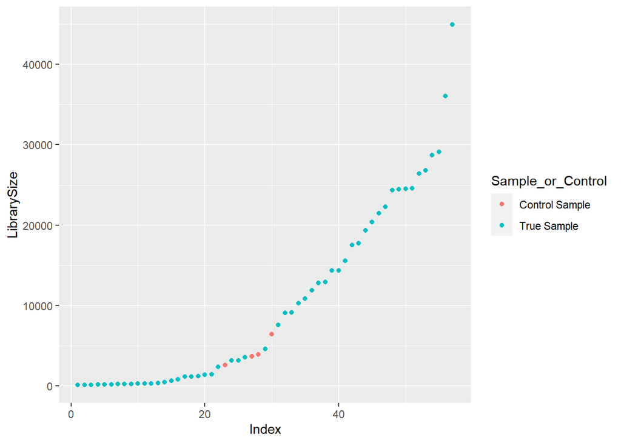

```r
library(decontam)
df <- as.data.frame(sample_data(dataset.16S.ordi)) # Put sample_data into a ggplot-friendly data.frame
df$LibrarySize <- sample_sums(dataset.16S.ordi)
df <- df[order(df$LibrarySize),]
df$Index <- seq(nrow(df))
ggplot(data=df, aes(x=Index, y=LibrarySize, color=Sample_or_Control)) + geom_point()
```

```r
sample_data(dataset.16S.ordi)$is.neg <- sample_data(dataset.16S.ordi)$Sample_or_Control == "Control Sample"
contamdf.prev <- isContaminant(dataset.16S.ordi, method="prevalence", neg="is.neg")
table(contamdf.prev$contaminant)
```

```
##
## FALSE  TRUE
##   114   178
```

```r
ps.pa <- transform_sample_counts(dataset.16S.ordi, function(abund) 1*(abund>0))
ps.pa.neg <- prune_samples(sample_data(ps.pa)$Sample_or_Control == "Control Sample", ps.pa)
ps.pa.pos <- prune_samples(sample_data(ps.pa)$Sample_or_Control == "True Sample", ps.pa)
```

Make data.frame of prevalence in positive and negative samples

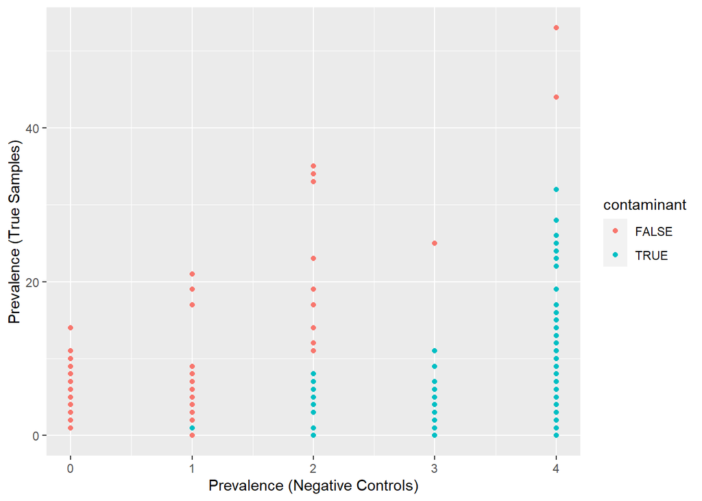

```r
df.pa <- data.frame(pa.pos=taxa_sums(ps.pa.pos), pa.neg=taxa_sums(ps.pa.neg),contaminant=contamdf.prev$contaminant)
ggplot(data=df.pa, aes(x=pa.neg, y=pa.pos, color=contaminant)) + geom_point() + xlab("Prevalence (Negative Controls)") + ylab("Prevalence (True Samples)")
```

```r
ps.noncontam_dataset.16S.ordi <- prune_taxa(!contamdf.prev$contaminant, dataset.16S.ordi)
ps.noncontam_dataset.16S.ordi
```

```
## phyloseq-class experiment-level object
## otu_table()   OTU Table:         [ 114 taxa and 57 samples ]
## sample_data() Sample Data:       [ 57 samples by 17 sample variables ]
## tax_table()   Taxonomy Table:    [ 114 taxa by 8 taxonomic ranks ]
```

```r
smin <- min(sample_sums(ps.noncontam_dataset.16S.ordi))
smean <- mean(sample_sums(ps.noncontam_dataset.16S.ordi))
smax <- max(sample_sums(ps.noncontam_dataset.16S.ordi))
cat("The minimum sample read count is:",smin)
```

```
## The minimum sample read count is: 46
```

```r
cat("The average sample read count is:",smean)
```

```
## The average sample read count is: 9828.246
```

```r
cat("The maximum sample read count is:",smax)
```

```
## The maximum sample read count is: 44924
```

#### create a list of all excluded contaminants

```r
contaminants <- subset(contamdf.prev, contaminant == "TRUE")
```

## check and plot controls again

prepare data for plotting

```r
negs2 <- subset_samples(ps.noncontam_dataset.16S.ordi, Treatment == "negative" | Treatment == "medium")
negs2 <- prune_taxa(taxa_sums(negs2) > 0, negs2)

pos2 <- subset_samples(ps.noncontam_dataset.16S.ordi, Treatment == "standard")
pos2 <- prune_taxa(taxa_sums(pos2) > 0, pos2)

Bacteria_Genus.pos2 <- pos2 %>%
  tax_glom(taxrank = "Genus") %>%
  transform_sample_counts(function(x) {x/sum(x)} ) %>%
  psmelt() %>%
  arrange(Genus)

Bacteria_Genus.pos2$Genus<-as.character(Bacteria_Genus.pos2$Genus)
Bacteria_Genus.pos2$Genus[Bacteria_Genus.pos2$Abundance<0.01]<-"Others"
Bacteria_Genus.pos2$Class<-as.character(Bacteria_Genus.pos2$Class)
Bacteria_Genus.pos2$Class[Bacteria_Genus.pos2$Abundance<0.01]<-"Others"

Bacteria_Genus.neg2 <- negs2 %>%
  tax_glom(taxrank = "Genus") %>%
  transform_sample_counts(function(x) {x/sum(x)} ) %>%
  psmelt() %>%
  arrange(Genus)

Bacteria_Genus.neg2$Genus<-as.character(Bacteria_Genus.neg2$Genus)
Bacteria_Genus.neg2$Genus[Bacteria_Genus.neg2$Abundance<0.03]<-"Others"
Bacteria_Genus.neg2$Class<-as.character(Bacteria_Genus.neg2$Class)
Bacteria_Genus.neg2$Class[Bacteria_Genus.neg2$Abundance<0.03]<-"Others"
```

positive controls post decontam

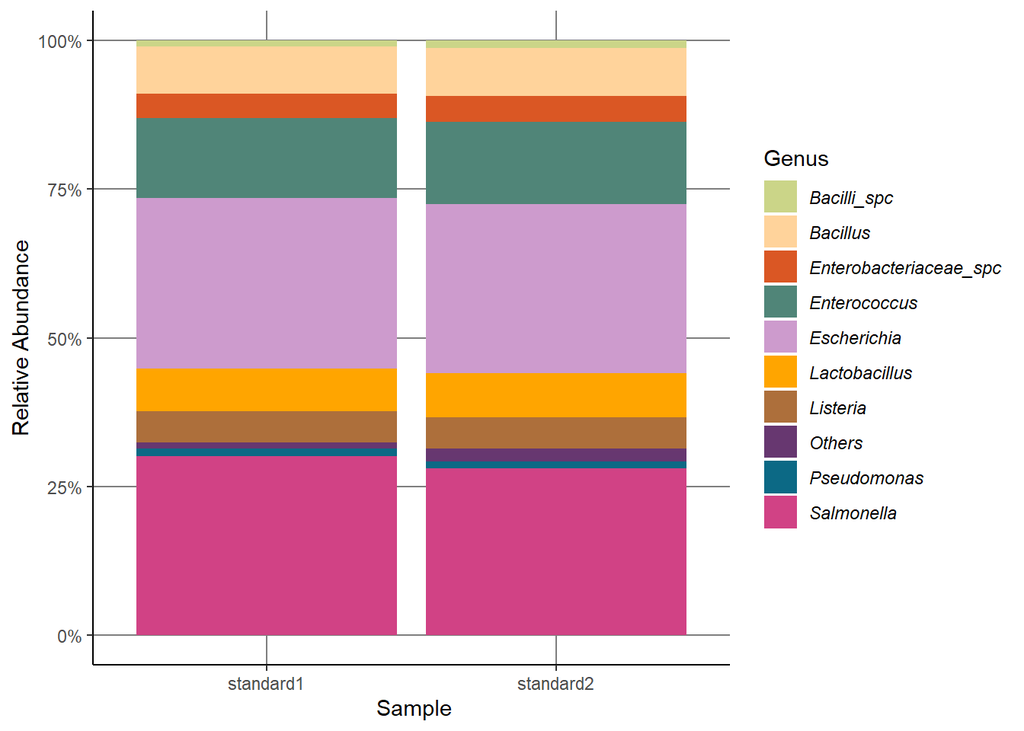

```r
Bacteria_Genus.pos2_plot <-ggplot(Bacteria_Genus.pos2, aes(x = Sample, y = Abundance, fill = Genus)) +
  geom_bar(stat = "identity", position="fill") +
  scale_fill_manual(values = Family_colors, name = "Genus")

g3<-Bacteria_Genus.pos2_plot +
  theme(plot.title = element_text(size = 20, face = "bold")) +
  theme(text = element_text(size=20, face = "bold"))+
  theme(axis.text.x=element_text(size = rel(0.5)))+
  theme(legend.title = element_text(size = 20), legend.text = element_text(size = 14))+
  theme_classic()+           #gets rid of background
  theme(panel.grid.major = element_line(colour = "grey50"))+
  labs(x=" Sample", y="Relative Abundance")+
  scale_y_continuous(labels=percent_format())+
  theme(legend.text = element_text(face = "italic"))

g3
```

negative controls post decontam

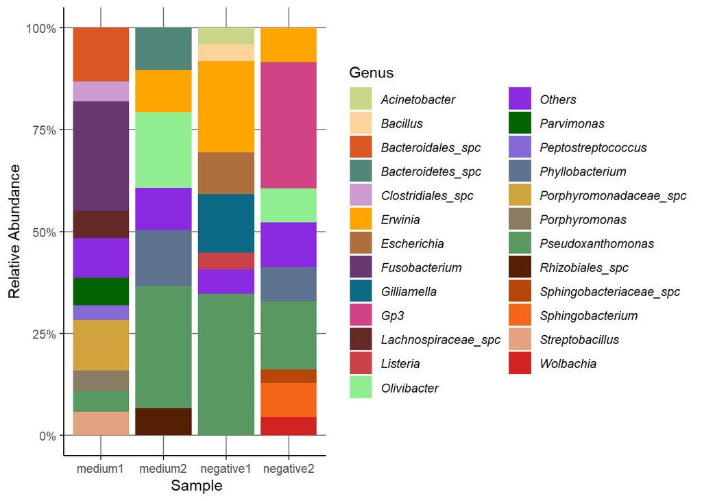

```r
Bacteria_Genus.neg2_plot <-ggplot(Bacteria_Genus.neg2, aes(x = Sample, y = Abundance, fill = Genus)) +
  geom_bar(stat = "identity", position="fill") +
  scale_fill_manual(values = Family_colors, name = "Genus")

g4<-Bacteria_Genus.neg2_plot +
  theme(plot.title = element_text(size = 20, face = "bold")) +
  theme(text = element_text(size=20, face = "bold"))+
  theme(axis.text.x=element_text(size = rel(0.5)))+
  theme(legend.title = element_text(size = 20), legend.text = element_text(size = 14))+
  theme_classic()+           #gets rid of background
  theme(panel.grid.major = element_line(colour = "grey50"))+
  labs(x=" Sample", y="Relative Abundance")+
  scale_y_continuous(labels=percent_format())+
  theme(legend.text = element_text(face = "italic"))

g4
```

```r
bac.without.controls <- subset_samples(ps.noncontam_dataset.16S.ordi, Treatment!="medium")
bac.without.controls2 <- subset_samples(bac.without.controls, Treatment!="negative")
bwc <- subset_samples(bac.without.controls2, Treatment!="standard")
```

### now have a look at the 15 most abundant ZOTUS in our samples

```r
most.abundant<-subset_samples(bwc, Treatment=="control" | Treatment=="removal" | Treatment=="2nd-foundation")

filtaxa <- names (sort(rowSums(otu_table(most.abundant)) ,decreasing=T))[1:15]
tax_table(bwc)[filtaxa]
```

```
## Taxonomy Table:     [15 taxa by 8 taxonomic ranks]:
##                                   Domain     Phylum
## Zotu2:Pseudoxanthomonas_spadix    "Bacteria" "Proteobacteria"
## Zotu5:Erwinia_spc                 "Bacteria" "Proteobacteria"
## Zotu8:Ochrobactrum_spc            "Bacteria" "Proteobacteria"
## Zotu7:Wolbachia_spc               "Bacteria" "Proteobacteria"
## Zotu21:Microbacterium_pygmaeum    "Bacteria" "Actinobacteria"
## Zotu24:Wolbachia_spc              "Bacteria" "Proteobacteria"
## Zotu110:Enterobacteriaceae_spc    "Bacteria" "Proteobacteria"
## Zotu45:Pseudoxanthomonas_spc      "Bacteria" "Proteobacteria"
## Zotu49:Microbacterium_pygmaeum    "Bacteria" "Actinobacteria"
## Zotu9:Erwinia_spc                 "Bacteria" "Proteobacteria"
## Zotu48:Microbacterium_spc         "Bacteria" "Actinobacteria"
## Zotu93:Stenotrophomonas_spc       "Bacteria" "Proteobacteria"
## Zotu89:Pseudoxanthomonas_spc      "Bacteria" "Proteobacteria"
## Zotu51:Microbacterium_spc         "Bacteria" "Actinobacteria"
## Zotu43:Phyllobacterium_catacumbae "Bacteria" "Proteobacteria"
##                                   Class                 Order
## Zotu2:Pseudoxanthomonas_spadix    "Gammaproteobacteria" "Xanthomonadales"
## Zotu5:Erwinia_spc                 "Gammaproteobacteria" "Enterobacteriales"
## Zotu8:Ochrobactrum_spc            "Alphaproteobacteria" "Rhizobiales"
## Zotu7:Wolbachia_spc               "Alphaproteobacteria" "Rickettsiales"
## Zotu21:Microbacterium_pygmaeum    "Actinobacteria"      "Actinomycetales"
## Zotu24:Wolbachia_spc              "Alphaproteobacteria" "Rickettsiales"
## Zotu110:Enterobacteriaceae_spc    "Gammaproteobacteria" "Enterobacteriales"
## Zotu45:Pseudoxanthomonas_spc      "Gammaproteobacteria" "Xanthomonadales"
## Zotu49:Microbacterium_pygmaeum    "Actinobacteria"      "Actinomycetales"
## Zotu9:Erwinia_spc                 "Gammaproteobacteria" "Enterobacteriales"
## Zotu48:Microbacterium_spc         "Actinobacteria"      "Actinomycetales"
## Zotu93:Stenotrophomonas_spc       "Gammaproteobacteria" "Xanthomonadales"
## Zotu89:Pseudoxanthomonas_spc      "Gammaproteobacteria" "Xanthomonadales"
## Zotu51:Microbacterium_spc         "Actinobacteria"      "Actinomycetales"
## Zotu43:Phyllobacterium_catacumbae "Alphaproteobacteria" "Rhizobiales"
##                                   Family               Genus
## Zotu2:Pseudoxanthomonas_spadix    "Xanthomonadaceae"   "Pseudoxanthomonas"
## Zotu5:Erwinia_spc                 "Enterobacteriaceae" "Erwinia"
## Zotu8:Ochrobactrum_spc            "Brucellaceae"       "Ochrobactrum"
## Zotu7:Wolbachia_spc               "Rickettsiaceae"     "Wolbachia"
## Zotu21:Microbacterium_pygmaeum    "Microbacteriaceae"  "Microbacterium"
## Zotu24:Wolbachia_spc              "Rickettsiaceae"     "Wolbachia"
```

[output cut: 26 more lines]

```
## Zotu2:Pseudoxanthomonas_spadix    "Zotu2:Pseudoxanthomonas_spadix"
## Zotu5:Erwinia_spc                 "Zotu5:Erwinia_spc"
## Zotu8:Ochrobactrum_spc            "Zotu8:Ochrobactrum_spc"
## Zotu7:Wolbachia_spc               "Zotu7:Wolbachia_spc"
## Zotu21:Microbacterium_pygmaeum    "Zotu21:Microbacterium_pygmaeum"
## Zotu24:Wolbachia_spc              "Zotu24:Wolbachia_spc"
## Zotu110:Enterobacteriaceae_spc    "Zotu110:Enterobacteriaceae_spc"
## Zotu45:Pseudoxanthomonas_spc      "Zotu45:Pseudoxanthomonas_spc"
## Zotu49:Microbacterium_pygmaeum    "Zotu49:Microbacterium_pygmaeum"
## Zotu9:Erwinia_spc                 "Zotu9:Erwinia_spc"
## Zotu48:Microbacterium_spc         "Zotu48:Microbacterium_spc"
## Zotu93:Stenotrophomonas_spc       "Zotu93:Stenotrophomonas_spc"
## Zotu89:Pseudoxanthomonas_spc      "Zotu89:Pseudoxanthomonas_spc"
## Zotu51:Microbacterium_spc         "Zotu51:Microbacterium_spc"
## Zotu43:Phyllobacterium_catacumbae "Zotu43:Phyllobacterium_catacumbae"
```

```r
round(otu_table(bwc)[filtaxa], digits = 4)
```

```
## OTU Table:          [15 taxa and 51 samples]
##                      taxa are rows
##                                   B0-19a B0-19b B0-22a B0-22b B0-24 B0-27
## Zotu2:Pseudoxanthomonas_spadix     16671  17059     42     16   319    13
## Zotu5:Erwinia_spc                      0      0     33     10    44     3
## Zotu8:Ochrobactrum_spc                 2      1      1      0    23     0
## Zotu7:Wolbachia_spc                    1      0    895   2281   679   746
## Zotu21:Microbacterium_pygmaeum       323    293     25      9     3    15
## Zotu24:Wolbachia_spc                   0     22      0      0    32     0
## Zotu110:Enterobacteriaceae_spc         0      0      0      0     0     0
## Zotu45:Pseudoxanthomonas_spc          21    124      0      0     0     0
## Zotu49:Microbacterium_pygmaeum        76     46      0      0     1     0
## Zotu9:Erwinia_spc                      0      0      0      0     0     0
## Zotu48:Microbacterium_spc             58     40      0      0     0     0
## Zotu93:Stenotrophomonas_spc            0      0      0      0     0     0
## Zotu89:Pseudoxanthomonas_spc           0      0      0      0     0     0
## Zotu51:Microbacterium_spc             62     40      0      0     0     0
## Zotu43:Phyllobacterium_catacumbae      1      2      1      1    23     3
##                                   B10-01 B10-06 B10-09a B10-09b B10-18 B10-24
## Zotu2:Pseudoxanthomonas_spadix        16     35      76      29     24     35
## Zotu5:Erwinia_spc                      0      4       9       2     10      0
## Zotu8:Ochrobactrum_spc                 1      1       1       0      1      0
## Zotu7:Wolbachia_spc                    0      2       1       1      6      0
## Zotu21:Microbacterium_pygmaeum         0      0       0       0      0      0
## Zotu24:Wolbachia_spc                 222    121       2       0    100    135
## Zotu110:Enterobacteriaceae_spc         0      0       0       0      0      0
## Zotu45:Pseudoxanthomonas_spc           0      0       0       0      0      0
## Zotu49:Microbacterium_pygmaeum         0      0       0       0      0      0
## Zotu9:Erwinia_spc                      1      0       0       0      0      0
## Zotu48:Microbacterium_spc              0      0       0       0      0      0
## Zotu93:Stenotrophomonas_spc            0      0       0       0      0      0
## Zotu89:Pseudoxanthomonas_spc           0      0       0       0      0      0
## Zotu51:Microbacterium_spc              0      0       0       0      0      0
## Zotu43:Phyllobacterium_catacumbae      0      0       0       0      4      0
##                                   B10-25a B10-25b B10-26a B15-01a B15-01b
## Zotu2:Pseudoxanthomonas_spadix         29      28      60     181      11
## Zotu5:Erwinia_spc                       2       2      89      85       0
## Zotu8:Ochrobactrum_spc                  1       0       1       1       0
## Zotu7:Wolbachia_spc                     0       0       1       0     163
## Zotu21:Microbacterium_pygmaeum          0       1       0       0       0
```

[output cut: 91 more lines]

```
## Zotu2:Pseudoxanthomonas_spadix     26359  26612    4077  14748 19215  12684
## Zotu5:Erwinia_spc                      3      6   24556     18     4      7
## Zotu8:Ochrobactrum_spc                 5      1       4      3     4     18
## Zotu7:Wolbachia_spc                    5     28       2      1     9      1
## Zotu21:Microbacterium_pygmaeum         0      0       1    391     0      0
## Zotu24:Wolbachia_spc                   1     19       0     26    77      0
## Zotu110:Enterobacteriaceae_spc         0      0      42      0     0      0
## Zotu45:Pseudoxanthomonas_spc           0      0       0    161     2      0
## Zotu49:Microbacterium_pygmaeum         0      0       0     34     0      0
## Zotu9:Erwinia_spc                      0      0      56      0     0      0
## Zotu48:Microbacterium_spc              0      0       0     29     0      0
## Zotu93:Stenotrophomonas_spc            0      0      88      0     0      0
## Zotu89:Pseudoxanthomonas_spc           0      0      83      0     0      0
## Zotu51:Microbacterium_spc              0      0       0     40     0      0
## Zotu43:Phyllobacterium_catacumbae      0      1      27      2     1      2
```

### create subset of dataset

subset dataset bwc and exclude samples with low read counts (<500 reads)

```r
sample_data(bwc)$ColSums <- colSums(otu_table(bwc))
high.reads <- subset_samples(bwc, ColSums>500)
```

reduce metadata

```r
sample_data(high.reads) <- sample_data(high.reads)[,c("Sample","Nest","Linage","Treatment", "age_sampling_d", "Group")]
```

get rid of no read taxa in dataset

```r
high.reads <- prune_taxa(taxa_sums(high.reads) > 0, high.reads)
```

extract general information on data

```r
microbiome::summarize_phyloseq(high.reads)
```

```
## Compositional = NO2
```

[output not shown]

```
## [[1]]
## [1] "1] Min. number of reads = 793"
##
## [[2]]
## [1] "2] Max. number of reads = 44924"
##
## [[3]]
## [1] "3] Total number of reads = 540422"
##
## [[4]]
## [1] "4] Average number of reads = 15011.7222222222"
##
## [[5]]
## [1] "5] Median number of reads = 14342"
##
## [[6]]
## [1] "7] Sparsity = 0.799919484702093"
##
## [[7]]
## [1] "6] Any OTU sum to 1 or less? YES"
##
## [[8]]
## [1] "8] Number of singletons = 5"
##
## [[9]]
## [1] "9] Percent of OTUs that are singletons \n        (i.e. exactly one read detected across all samples)7.2463768115942"
##
## [[10]]
## [1] "10] Number of sample variables are: 6"
##
## [[11]]
## [1] "Sample"         "Nest"           "Linage"         "Treatment"
## [5] "age_sampling_d" "Group"
```

```r
replicates <- subset.data.frame(sample_data(high.reads))
table(replicates$Treatment)
```

```
##
## 2nd-foundation        control        removal
##              8             14             14
```

# **Analysis**

## Rarefaction curves

1. all samples with controls
2. all samples with controls decontaminated
3. all samples without controls
4. all samples >500 reads

Rarefaction is used to simulate even number of reads per sample.

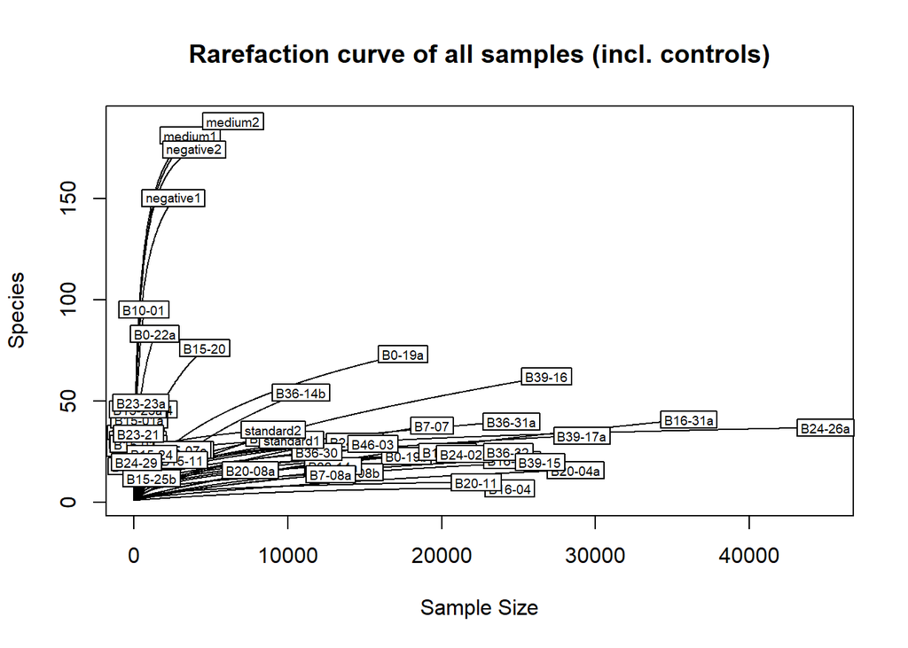

```r
rarecurve(t(otu_table(dataset.16S.ordi)), cex=0.6, step = 20, main = "Rarefaction curve of all samples (incl. controls)")
```

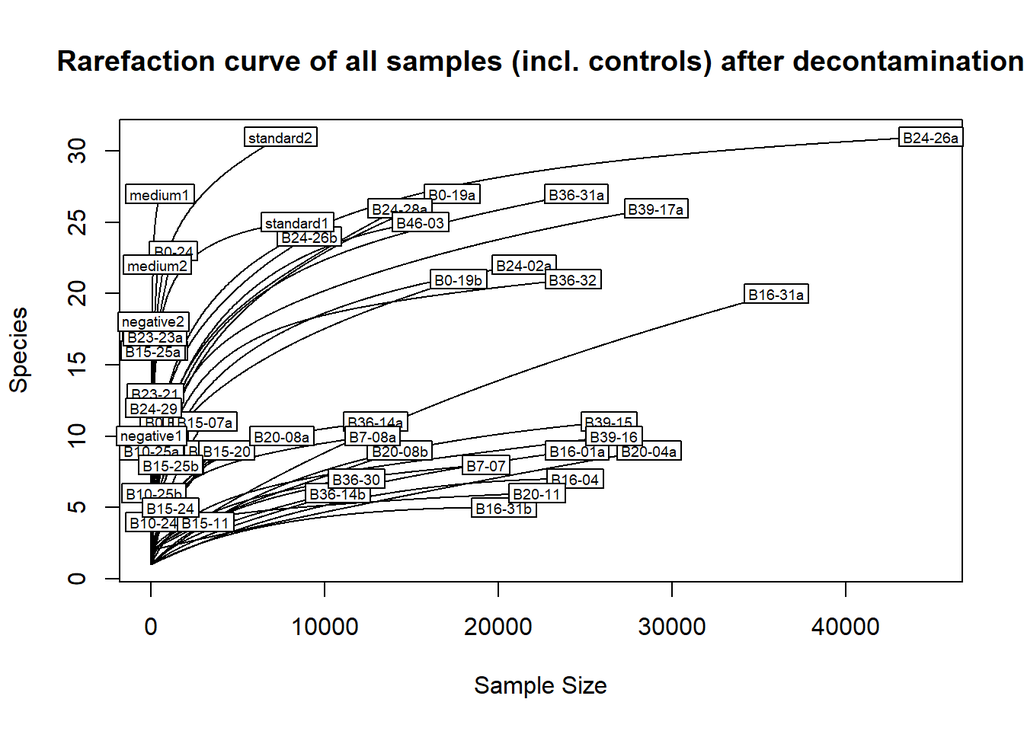

```r
rarecurve(t(otu_table(ps.noncontam_dataset.16S.ordi)), cex=0.6, step = 20, main = "Rarefaction curve of all samples (incl. controls) after decontamination")
```

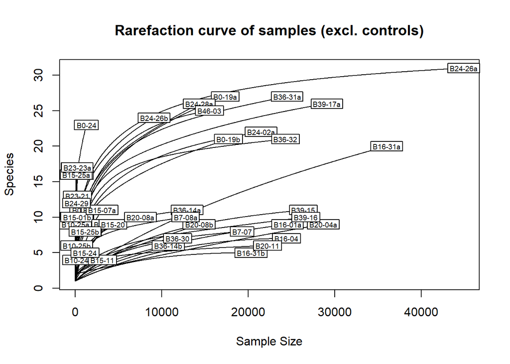

```r
rarecurve(t(otu_table(bwc)), cex=0.6, step = 20, main = "Rarefaction curve of samples (excl. controls)")
```

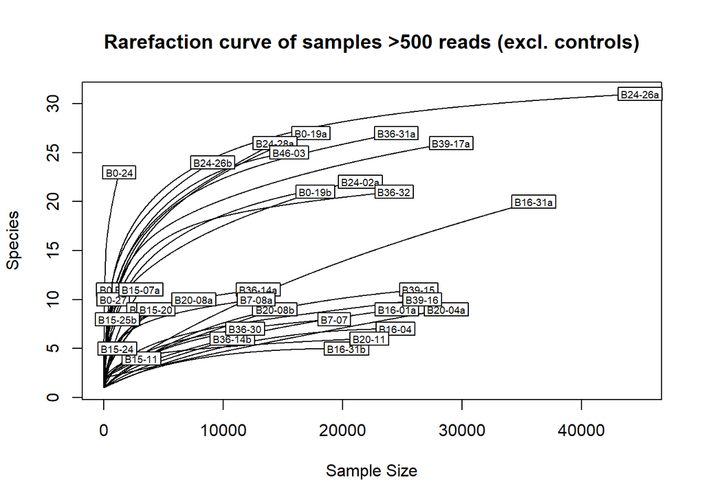

```r
rarecurve(t(otu_table(high.reads)), cex=0.6, step = 20, main = "Rarefaction curve of samples >500 reads (excl. controls)")
```

### rarefy dataset to 2000 reads

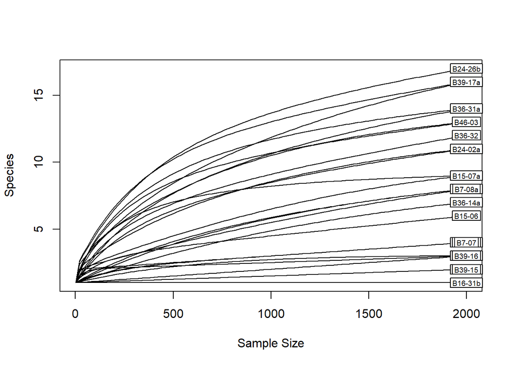

```r
ps2 <-high.reads
set.seed(1)
ps2 <- rarefy_even_depth(ps2,sample.size=2000, replace=FALSE, rngseed = 1)
rarecurve(t(otu_table(ps2)), cex=0.6, step = 20)
```

–> 6 samples removed because they contained fewer reads than `sample.size`. Up to first five removed samples are: B0-22a B0-24 B0-27 B15-07b B15-24 …

15OTUs were removed because they are no longer present in any sample after random subsampling

### subset data to two comparison groups

```r
#control vs. removal
CR <- subset_samples(high.reads, Treatment!="2nd-foundation")
CRrf <- subset_samples(ps2, Treatment!="2nd-foundation")

#removal vs. 2^nd^ attempt
R2nd <- subset_samples(high.reads, Treatment!="control")
R2ndrf <- subset_samples(ps2, Treatment!="control")
```

## **Alpha diversity**

### **Diversity plots**

This returns a table with selected diversity indicators (Shannon diversity & Observed richness).

```r
tabCR <- microbiome::alpha(CRrf, index = c("diversity_shannon","observed"))

tabR2nd <- microbiome::alpha(R2ndrf, index = c("diversity_shannon","observed"))
```

#### Prepare data for vizualisation

Now, get the metadata (sample_data) from the phyloseq object

```r
ps1.meta.CR <- meta(CRrf)

ps1.meta.R2nd <- meta(R2ndrf)
```

Add the diversity table to metadata

```r
ps1.meta.CR$Shannon <- tabCR$diversity_shannon
ps1.meta.CR$Observed <- tabCR$observed

ps1.meta.R2nd$Shannon <- tabR2nd$diversity_shannon
ps1.meta.R2nd$Observed <- tabR2nd$observed
```

#### plot

control vs. removal (rarefied, 2000 reads)

```r
ps1.meta.CR$Treatment <- as.factor(ps1.meta.CR$Treatment)
ps1.meta.CR$Treatment <- factor(ps1.meta.CR$Treatment, levels = c("control", "removal"))

#Shannon diversity index
(a <- summaryBy(Shannon ~ Treatment, ps1.meta.CR, FUN = c(mean, sd)))
```

```
##   Treatment Shannon.mean Shannon.sd
## 1   control    0.1539935  0.1977253
## 2   removal    0.2550152  0.2528587
```

```r
p1 <- ggplot(ps1.meta.CR, aes(x = Treatment, y = Shannon))
shan_bac <- p1 + geom_jitter(position = position_jitter(w=0.2, h=0.1))+
    geom_pointrange(data = a, mapping = aes(x = Treatment, y = Shannon.mean, ymin = Shannon.mean-Shannon.sd, ymax = Shannon.mean + Shannon.sd), size = .9, color = "brown4")+
    theme_bw()+
    ylim(NA, 0.95)+
    labs(x = "Treatment group", y = "Shannon Diversity Index")+
  theme(axis.title = element_text(size = 18, face = "bold"), axis.text = element_text(size = 16))

#Observed richness
(b <- summaryBy(Observed ~ Treatment, ps1.meta.CR, FUN = c(mean, sd)))
```

```
##   Treatment Observed.mean Observed.sd
## 1   control      5.454545    3.933539
## 2   removal      9.769231    4.585373
```

```r
p2 <- ggplot(ps1.meta.CR, aes(x = Treatment, y = Observed))
obs_bac <- p2 + geom_jitter(position = position_jitter(w=0.2, h=0.1))+
    geom_pointrange(data = b, mapping = aes(x = Treatment, y = Observed.mean, ymin = Observed.mean-Observed.sd, ymax = Observed.mean + Observed.sd), size = .9, color = "brown4")+
    theme_bw()+
    ylim(NA, 17.5)+
    labs(x = "Treatment group", y = "Observed richness")+
  theme(axis.title = element_text(size = 18, face = "bold"), axis.text = element_text(size = 16))
```

removal vs. 2<sup>nd</sup> attempt (rarefied, 2000 reads)

```r
ps1.meta.R2nd$Treatment <- as.factor(ps1.meta.R2nd$Treatment)
ps1.meta.R2nd$Treatment <- factor(ps1.meta.R2nd$Treatment, levels = c("removal", "2nd-foundation"), labels = c("removal", "2nd-attempt"))

#Shannon diversity index
(c <- summaryBy(Shannon ~ Treatment, ps1.meta.R2nd, FUN = c(mean, sd)))
```

```
##     Treatment Shannon.mean Shannon.sd
## 1     removal    0.2550152  0.2528587
## 2 2nd-attempt    0.2270820  0.3171305
```

```r
p3 <- ggplot(ps1.meta.R2nd, aes(x = Treatment, y = Shannon))
shan_bac2<- p3 + geom_jitter(position = position_jitter(w=0.2, h=0.1))+
    geom_pointrange(data = c, mapping = aes(x = Treatment, y = Shannon.mean, ymin = Shannon.mean-Shannon.sd, ymax = Shannon.mean + Shannon.sd), size = .9, color = "brown4")+
    theme_bw()+
    ylim(NA, 1)+
    labs(x = "Treatment group", y = "Shannon Diversity Index")+
  theme(axis.title = element_text(size = 18, face = "bold"), axis.text = element_text(size = 16))

#Observed richness
(d <- summaryBy(Observed ~ Treatment, ps1.meta.R2nd, FUN = c(mean, sd)))
```

```
##     Treatment Observed.mean Observed.sd
## 1     removal      9.769231    4.585373
## 2 2nd-attempt      7.166667    6.274286
```

```r
p4 <- ggplot(ps1.meta.R2nd, aes(x = Treatment, y = Observed))
obs_bac2 <- p4 + geom_jitter(position = position_jitter(w=0.2, h=0.1))+
    geom_pointrange(data = d, mapping = aes(x = Treatment, y = Observed.mean, ymin = Observed.mean-Observed.sd, ymax = Observed.mean + Observed.sd), size = .9, color = "brown4")+
    theme_bw()+
    ylim(NA, 18.5)+
    labs(x = "Treatment group", y = "Observed richness")+
  theme(axis.title = element_text(size = 18, face = "bold"), axis.text = element_text(size = 16))
```

add statistical data output to plot

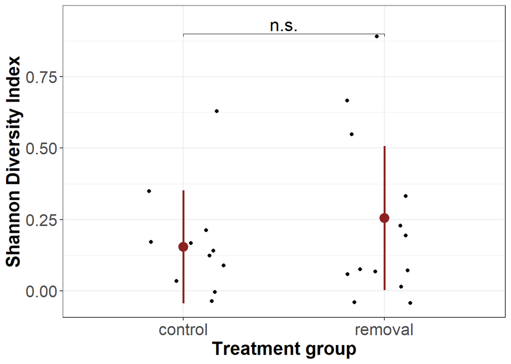

```r
shan_bac <- shan_bac + font("axis.title", size = 18)+
        font("xylab", size = 18)+
        geom_bracket(
            xmin = "control", xmax = "removal", y.position = 0.9, label = "n.s.", label.size = 6,tip.length = 0.01)

shan_bac
```

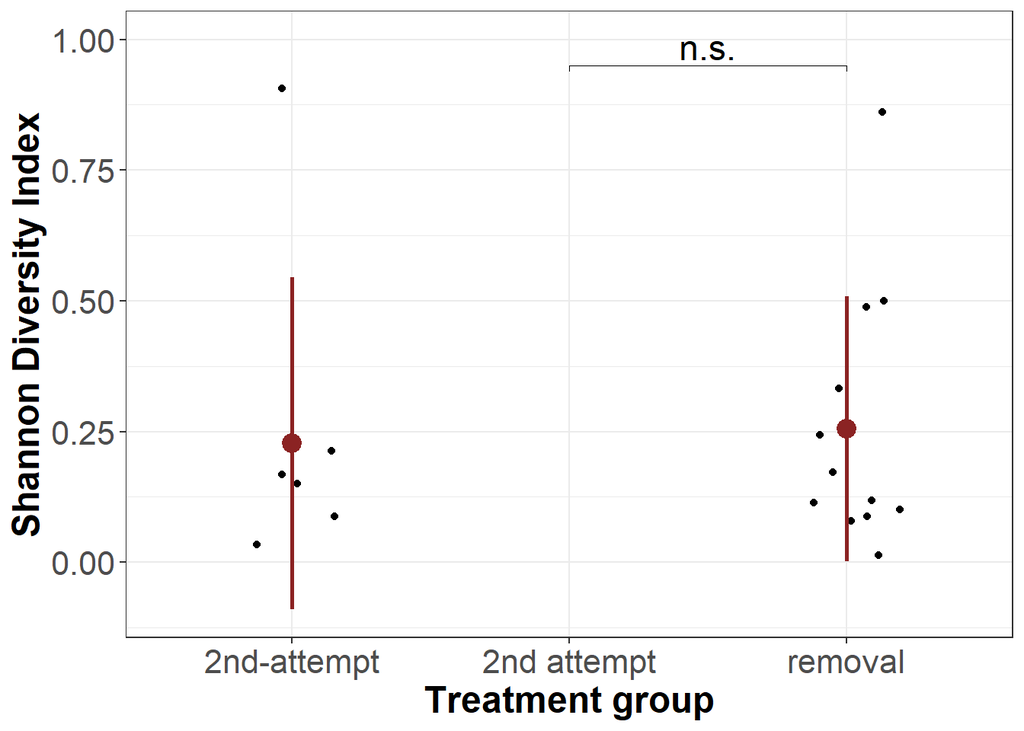

```r
shan_bac2 <- shan_bac2 + font("axis.title", size = 18)+
        font("xylab", size = 18)+
        geom_bracket(
            xmin = "removal", xmax = "2nd attempt", y.position = 0.95, label = "n.s.", label.size = 6,tip.length = 0.01)

shan_bac2
```

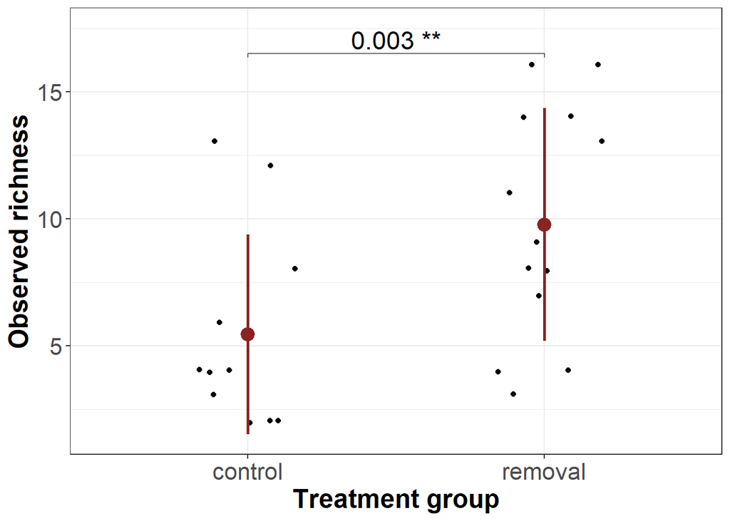

```r
obs_bac <- obs_bac + font("axis.title", size = 18)+
        font("xylab", size = 18)+
        geom_bracket(
            xmin = "control", xmax = "removal", y.position = 16.5, label = "0.003 **", label.size = 6,tip.length = 0.01)

obs_bac
```

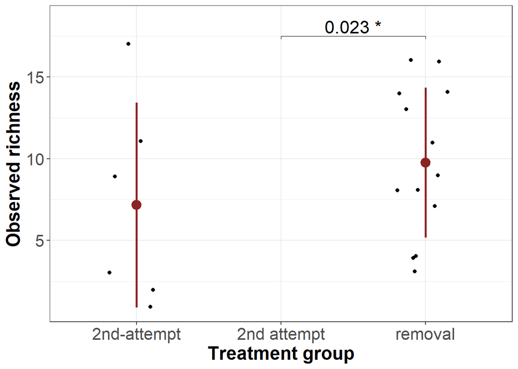

```r
obs_bac2 <- obs_bac2 + font("axis.title", size = 18)+
        font("xylab", size = 18)+
        geom_bracket(
            xmin = "removal", xmax = "2nd attempt", y.position = 17.5, label = "0.023 *", label.size = 6,tip.length = 0.01)

obs_bac2
```

### **Statistics**

Testing differences in alpha diversity

create dataframe for analysis

```r
#control vs. removal
dCR <- meta(CRrf)
shannon <- diversity(CRrf, "shannon")
dCR$shannon <- shannon$shannon
observed <- alpha(CRrf, index = "observed", zeroes = TRUE)
dCR$observed <- observed$observed

#removal vs. 2^nd^ attempt
dR2nd <- meta(R2ndrf)
shannon <- diversity(R2ndrf, "shannon")
dR2nd$shannon <- shannon$shannon
observed <- alpha(R2ndrf, index = "observed", zeroes = TRUE)
dR2nd$observed <- observed$observed
```

#### **Shannon diversity**

test distribution

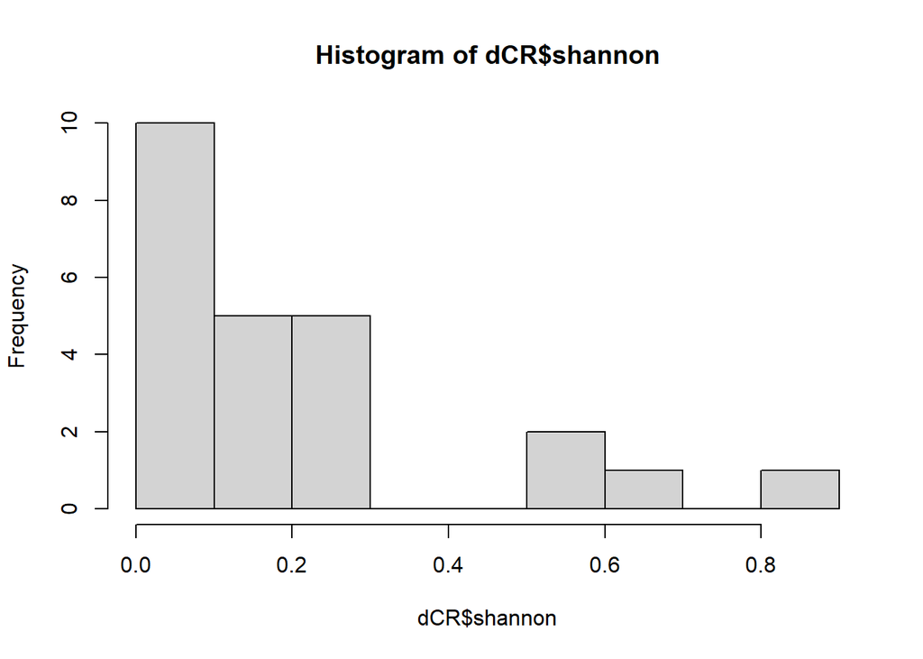

```r
hist(dCR$shannon)
```

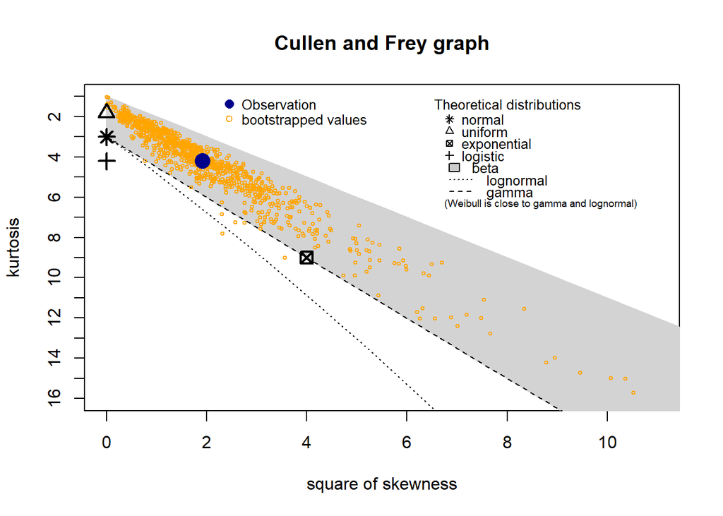

```
## summary statistics
## ------
## min:  0.004300326   max:  0.8266148
## median:  0.1338609
## mean:  0.2087136
## estimated sd:  0.2302183
## estimated skewness:  1.383827
## estimated kurtosis:  4.203764
```

```r
descdist(dCR$shannon, boot = 1000)
```

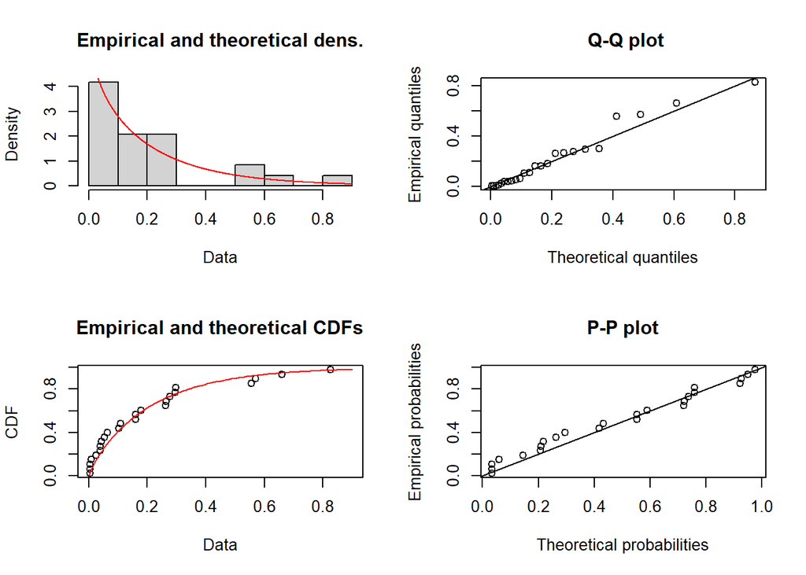

```r
fit.gamma <- fitdist(dCR$shannon, distr = "gamma", method = "mme")
plot(fit.gamma)
```

–> gamma distribution fits well

test with subset 1

```r
dCR$Treatment <- as.factor(dCR$Treatment)
dCR <- within(dCR, Treatment <- relevel(Treatment, ref = "control"))

shan1 <- glm(shannon ~ Treatment + Linage, family = Gamma("log"), data = dCR)
Anova(shan1, type = "II")
```

```
## Analysis of Deviance Table (Type II tests)
##
## Response: shannon
##           LR Chisq Df Pr(>Chisq)
## Treatment   1.5711  1    0.21005
## Linage     19.2578  8    0.01354 *
## ---
## Signif. codes:  0 '***' 0.001 '**' 0.01 '*' 0.05 '.' 0.1 ' ' 1
```

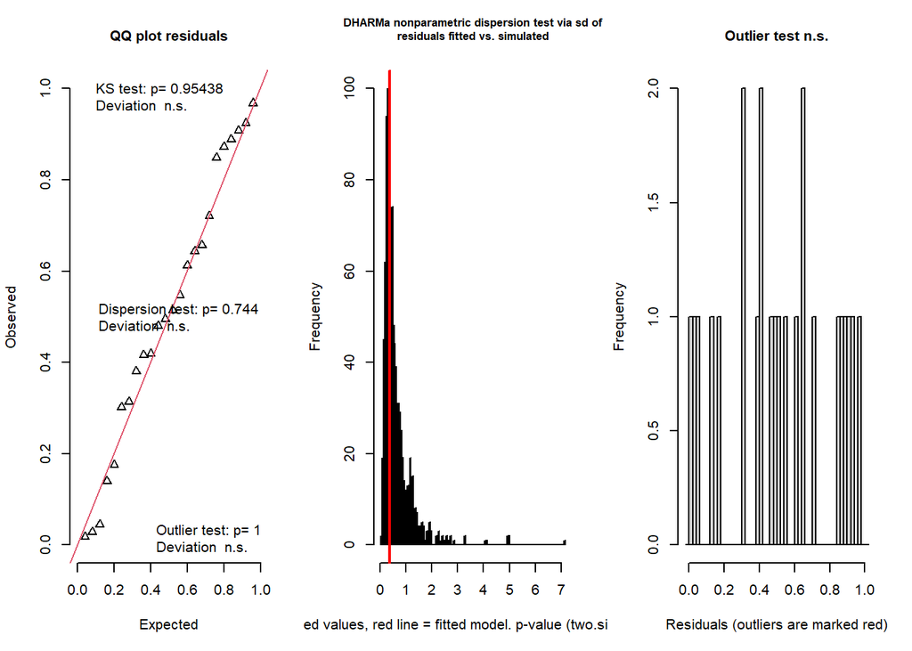

```
## $uniformity
##
##  One-sample Kolmogorov-Smirnov test
##
## data:  simulationOutput$scaledResiduals
## D = 0.099, p-value = 0.9544
## alternative hypothesis: two-sided
##
##
## $dispersion
##
##  DHARMa nonparametric dispersion test via sd of residuals fitted vs.
##  simulated
##
## data:  simulationOutput
## dispersion = 0.59005, p-value = 0.744
## alternative hypothesis: two.sided
##
##
## $outliers
##
##  DHARMa outlier test based on exact binomial test with approximate
##  expectations
##
## data:  simulationOutput
## outliers at both margin(s) = 0, observations = 24, p-value = 1
## alternative hypothesis: true probability of success is not equal to 0.001998002
## 95 percent confidence interval:
##  0.0000000 0.1424736
## sample estimates:
## frequency of outliers (expected: 0.001998001998002 )
##                                                    0
```

```
## $uniformity
##
##  One-sample Kolmogorov-Smirnov test
##
## data:  simulationOutput$scaledResiduals
## D = 0.099, p-value = 0.9544
## alternative hypothesis: two-sided
##
##
## $dispersion
##
##  DHARMa nonparametric dispersion test via sd of residuals fitted vs.
##  simulated
##
## data:  simulationOutput
## dispersion = 0.59005, p-value = 0.744
## alternative hypothesis: two.sided
##
##
## $outliers
##
##  DHARMa outlier test based on exact binomial test with approximate
##  expectations
##
## data:  simulationOutput
## outliers at both margin(s) = 0, observations = 24, p-value = 1
## alternative hypothesis: true probability of success is not equal to 0.001998002
## 95 percent confidence interval:
##  0.0000000 0.1424736
## sample estimates:
## frequency of outliers (expected: 0.001998001998002 )
##                                                    0
```

```r
res_shan1 <- simulateResiduals(shan1, n = 1000)
testResiduals(res_shan1)
```

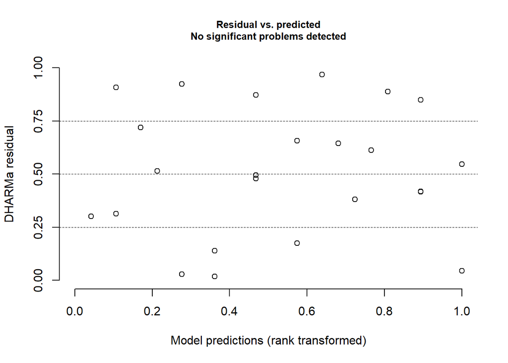

```r
plotResiduals(res_shan1)
```

test with subset 2

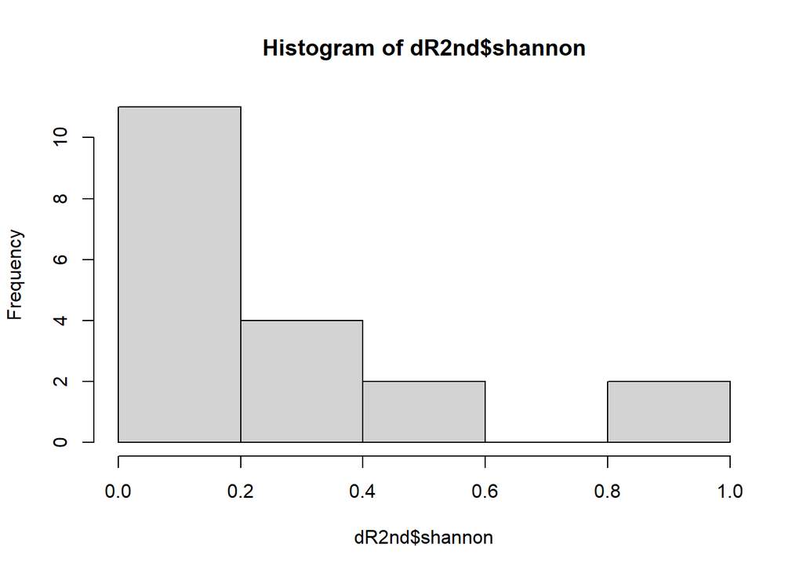

```r
hist(dR2nd$shannon)
```

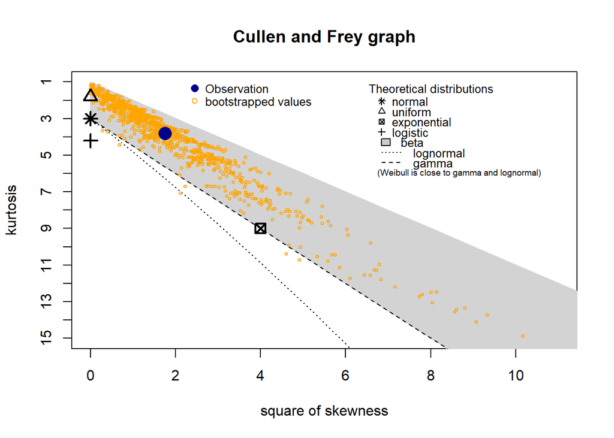

```
## summary statistics
## ------
## min:  0   max:  0.8483415
## median:  0.1594503
## mean:  0.2461942
## estimated sd:  0.2659691
## estimated skewness:  1.322517
## estimated kurtosis:  3.799409
```

```r
descdist(dR2nd$shannon, boot = 1000)
```

```r
logistic <- function(p) log(p / (1-p) +0.01)
shan1 <- lm(logistic(shannon) ~ Treatment + Linage, data = dR2nd)
Anova(shan1, type = "II")
```

```
## Anova Table (Type II tests)
##
## Response: logistic(shannon)
##           Sum Sq Df F value  Pr(>F)
## Treatment  0.622  1  0.4061 0.53829
## Linage    40.785  7  3.8062 0.02808 *
## Residuals 15.308 10
## ---
## Signif. codes:  0 '***' 0.001 '**' 0.01 '*' 0.05 '.' 0.1 ' ' 1
```

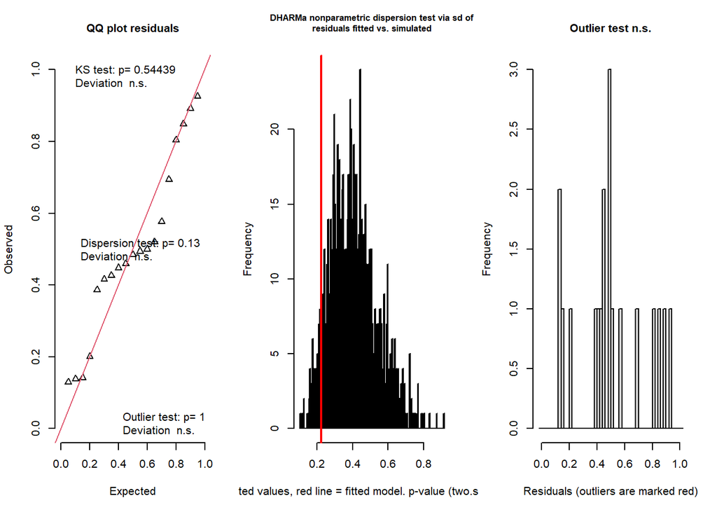

```
## $uniformity
##
##  One-sample Kolmogorov-Smirnov test
##
## data:  simulationOutput$scaledResiduals
## D = 0.17547, p-value = 0.5444
## alternative hypothesis: two-sided
##
##
## $dispersion
##
##  DHARMa nonparametric dispersion test via sd of residuals fitted vs.
##  simulated
##
## data:  simulationOutput
## dispersion = 0.55459, p-value = 0.13
## alternative hypothesis: two.sided
##
##
## $outliers
##
##  DHARMa outlier test based on exact binomial test with approximate
##  expectations
##
## data:  simulationOutput
## outliers at both margin(s) = 0, observations = 19, p-value = 1
## alternative hypothesis: true probability of success is not equal to 0.001998002
## 95 percent confidence interval:
##  0.0000000 0.1764669
## sample estimates:
## frequency of outliers (expected: 0.001998001998002 )
##                                                    0
```

```
## $uniformity
##
##  One-sample Kolmogorov-Smirnov test
##
## data:  simulationOutput$scaledResiduals
## D = 0.17547, p-value = 0.5444
## alternative hypothesis: two-sided
##
##
## $dispersion
##
##  DHARMa nonparametric dispersion test via sd of residuals fitted vs.
##  simulated
##
## data:  simulationOutput
## dispersion = 0.55459, p-value = 0.13
## alternative hypothesis: two.sided
##
##
## $outliers
##
##  DHARMa outlier test based on exact binomial test with approximate
##  expectations
##
## data:  simulationOutput
## outliers at both margin(s) = 0, observations = 19, p-value = 1
## alternative hypothesis: true probability of success is not equal to 0.001998002
## 95 percent confidence interval:
##  0.0000000 0.1764669
## sample estimates:
## frequency of outliers (expected: 0.001998001998002 )
##                                                    0
```

```r
res_shan1 <- simulateResiduals(shan1, n = 1000)
testResiduals(res_shan1)
```

#### **Observed richness**

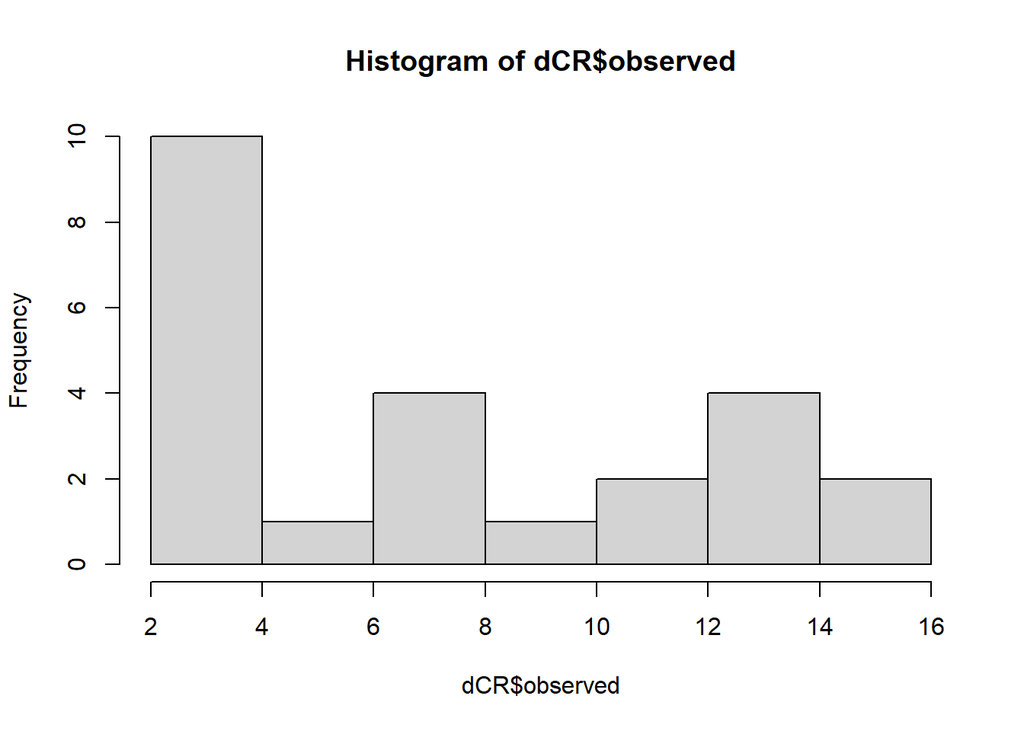

```r
hist(dCR$observed)
```

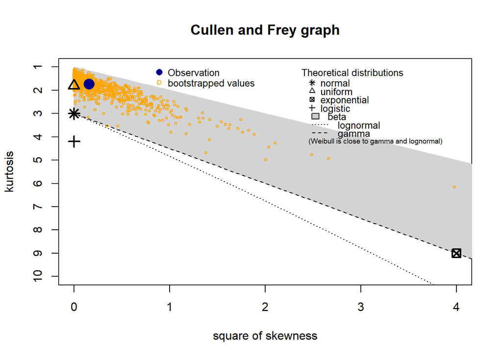

```
## summary statistics
## ------
## min:  2   max:  16
## median:  7.5
## mean:  7.791667
## estimated sd:  4.745517
## estimated skewness:  0.3971958
## estimated kurtosis:  1.7269
```

```r
descdist(dCR$observed, boot = 1000)
```

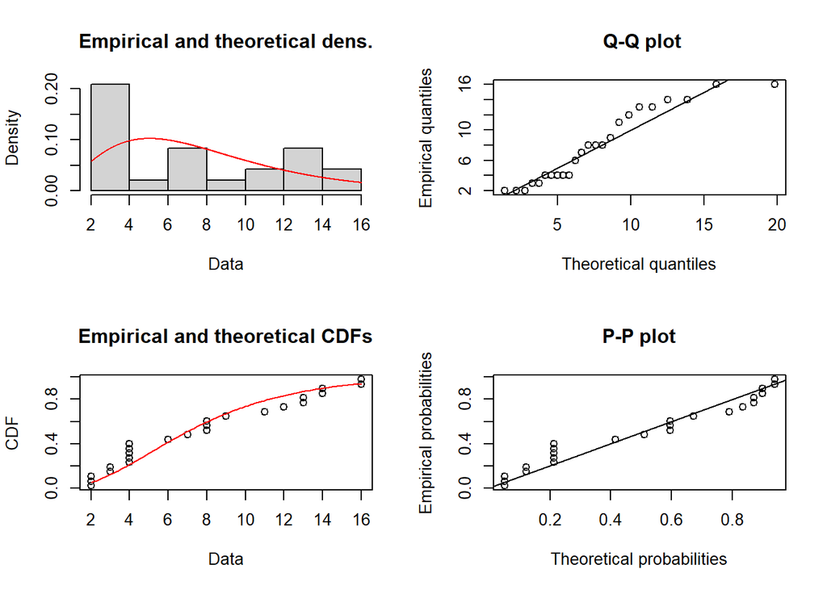

```r
fit.gamma <- fitdist(dCR$observed, distr = "gamma", method = "mme")
plot(fit.gamma)
```

–> gamma distribution fits well

test with subset 1

```r
dCR$Treatment <- as.factor(dCR$Treatment)
dCR <- within(dCR, Treatment <- relevel(Treatment, ref = "control"))

ob1 <- glm(observed ~ Treatment + Linage, family = Gamma("log"), data = dCR)
Anova(ob1, type = "II")
```

```
## Analysis of Deviance Table (Type II tests)
##
## Response: observed
##           LR Chisq Df Pr(>Chisq)
## Treatment   8.8115  1   0.002993 **
## Linage     19.3559  8   0.013068 *
## ---
## Signif. codes:  0 '***' 0.001 '**' 0.01 '*' 0.05 '.' 0.1 ' ' 1
```

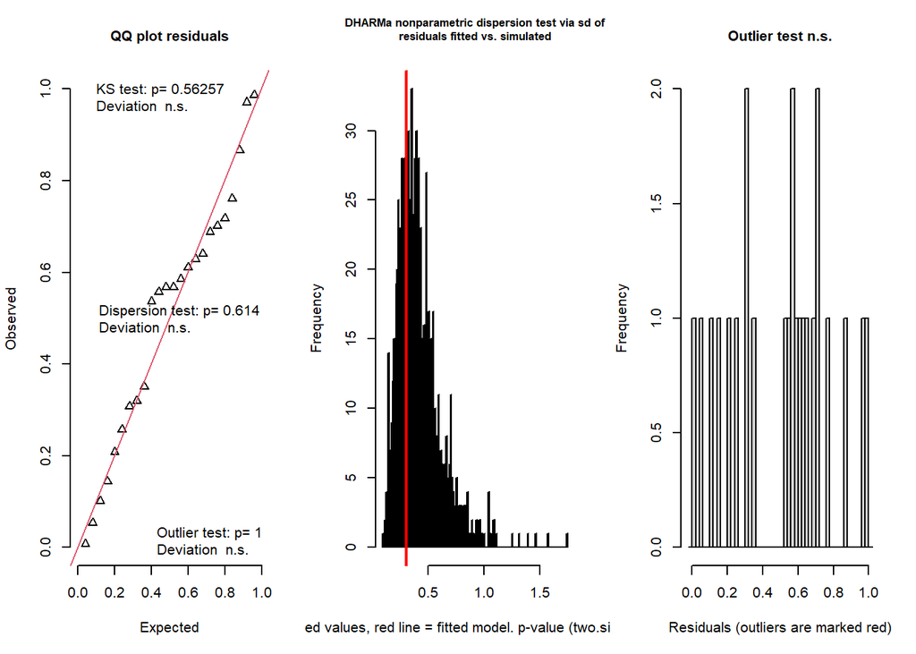

```
## $uniformity
##
##  One-sample Kolmogorov-Smirnov test
##
## data:  simulationOutput$scaledResiduals
## D = 0.161, p-value = 0.5626
## alternative hypothesis: two-sided
##
##
## $dispersion
##
##  DHARMa nonparametric dispersion test via sd of residuals fitted vs.
##  simulated
##
## data:  simulationOutput
## dispersion = 0.72767, p-value = 0.614
## alternative hypothesis: two.sided
##
##
## $outliers
##
##  DHARMa outlier test based on exact binomial test with approximate
##  expectations
##
## data:  simulationOutput
## outliers at both margin(s) = 0, observations = 24, p-value = 1
## alternative hypothesis: true probability of success is not equal to 0.001998002
## 95 percent confidence interval:
##  0.0000000 0.1424736
## sample estimates:
## frequency of outliers (expected: 0.001998001998002 )
##                                                    0
```

```
## $uniformity
##
##  One-sample Kolmogorov-Smirnov test
##
## data:  simulationOutput$scaledResiduals
## D = 0.161, p-value = 0.5626
## alternative hypothesis: two-sided
##
##
## $dispersion
##
##  DHARMa nonparametric dispersion test via sd of residuals fitted vs.
##  simulated
##
## data:  simulationOutput
## dispersion = 0.72767, p-value = 0.614
## alternative hypothesis: two.sided
##
##
## $outliers
##
##  DHARMa outlier test based on exact binomial test with approximate
##  expectations
##
## data:  simulationOutput
## outliers at both margin(s) = 0, observations = 24, p-value = 1
## alternative hypothesis: true probability of success is not equal to 0.001998002
## 95 percent confidence interval:
##  0.0000000 0.1424736
## sample estimates:
## frequency of outliers (expected: 0.001998001998002 )
##                                                    0
```

```r
res_ob1 <- simulateResiduals(ob1, n = 1000)
testResiduals(res_ob1)
```

test with subset 2

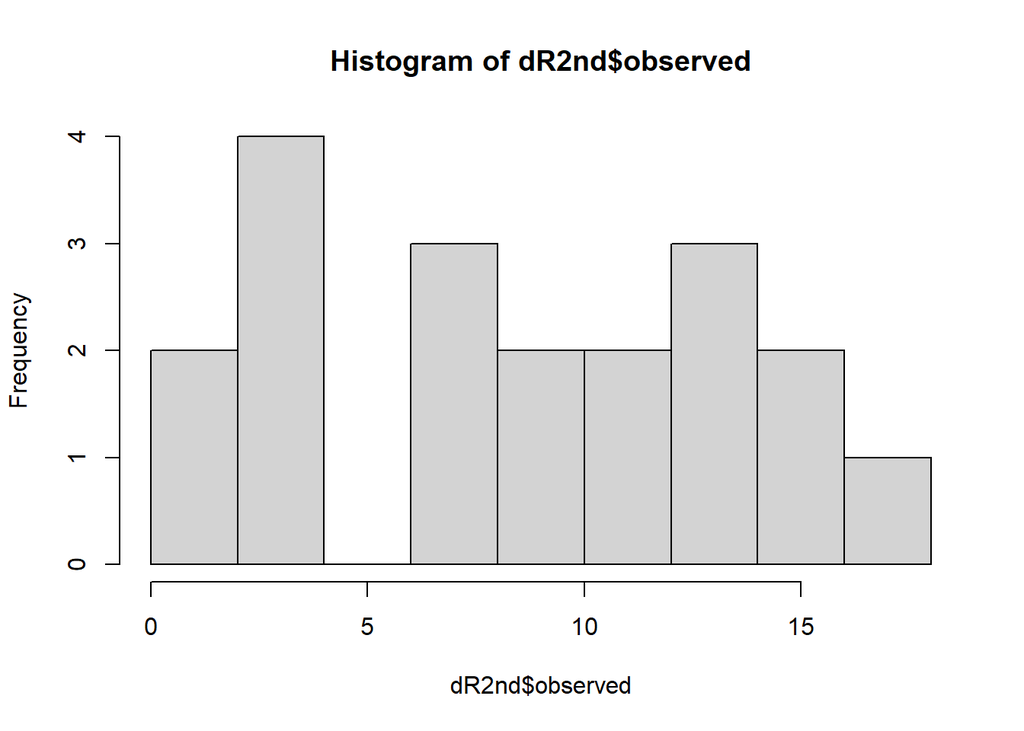

```r
hist(dR2nd$observed)
```

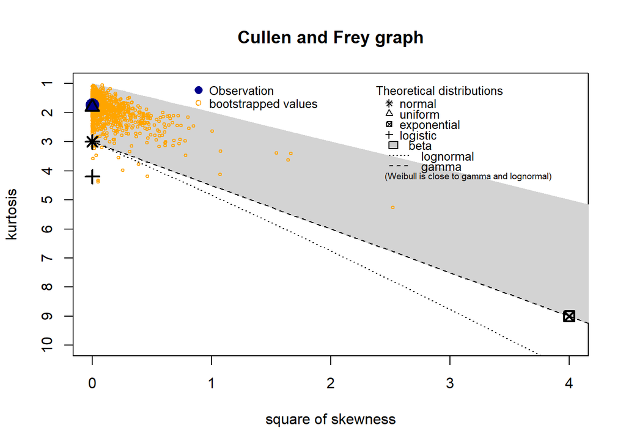

```
## summary statistics
## ------
## min:  1   max:  17
## median:  9
## mean:  8.947368
## estimated sd:  5.147531
## estimated skewness:  0.02563437
## estimated kurtosis:  1.725505
```

```r
descdist(dR2nd$observed, boot = 1000)
```

```r
ob2 <- glm(observed ~ Treatment + Linage, data = dR2nd, family = Gamma("log"))
Anova(ob2, type = "II")
```

```
## Analysis of Deviance Table (Type II tests)
##
## Response: observed
##           LR Chisq Df Pr(>Chisq)
## Treatment   5.1938  1  0.0226677 *
## Linage     29.2485  7  0.0001303 ***
## ---
## Signif. codes:  0 '***' 0.001 '**' 0.01 '*' 0.05 '.' 0.1 ' ' 1
```

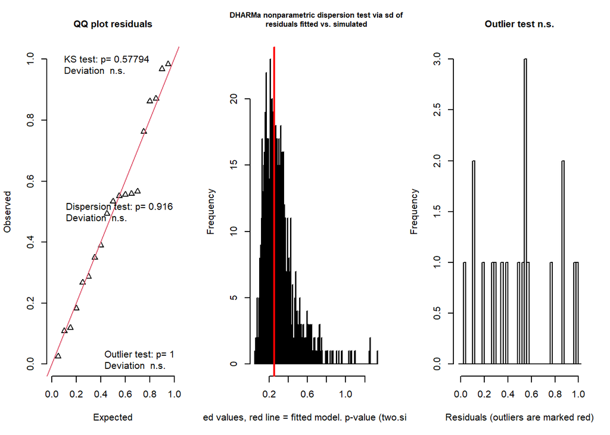

```
## $uniformity
##
##  One-sample Kolmogorov-Smirnov test
##
## data:  simulationOutput$scaledResiduals
## D = 0.17084, p-value = 0.5779
## alternative hypothesis: two-sided
##
##
## $dispersion
##
##  DHARMa nonparametric dispersion test via sd of residuals fitted vs.
##  simulated
##
## data:  simulationOutput
## dispersion = 0.84443, p-value = 0.916
## alternative hypothesis: two.sided
##
##
## $outliers
##
##  DHARMa outlier test based on exact binomial test with approximate
##  expectations
##
## data:  simulationOutput
## outliers at both margin(s) = 0, observations = 19, p-value = 1
## alternative hypothesis: true probability of success is not equal to 0.001998002
## 95 percent confidence interval:
##  0.0000000 0.1764669
## sample estimates:
## frequency of outliers (expected: 0.001998001998002 )
##                                                    0
```

```
## $uniformity
##
##  One-sample Kolmogorov-Smirnov test
##
## data:  simulationOutput$scaledResiduals
## D = 0.17084, p-value = 0.5779
## alternative hypothesis: two-sided
##
##
## $dispersion
##
##  DHARMa nonparametric dispersion test via sd of residuals fitted vs.
##  simulated
##
## data:  simulationOutput
## dispersion = 0.84443, p-value = 0.916
## alternative hypothesis: two.sided
##
##
## $outliers
##
##  DHARMa outlier test based on exact binomial test with approximate
##  expectations
##
## data:  simulationOutput
## outliers at both margin(s) = 0, observations = 19, p-value = 1
## alternative hypothesis: true probability of success is not equal to 0.001998002
## 95 percent confidence interval:
##  0.0000000 0.1764669
## sample estimates:
## frequency of outliers (expected: 0.001998001998002 )
##                                                    0
```

```r
res_ob2 <- simulateResiduals(ob2, n = 1000)
testResiduals(res_ob2)
```

## **Beta Diversity**

**Beta diversity and microbiome divergence**

Beta diversity quantifies dissimilarity in community composition between samples. Dissimilarity can be also quantified by distance or divergence. These measures have a broad use in statistical data analysis.

transform total abundance data into compositional data

```r
rel.CR <- CR %>%
  transform_sample_counts(function(x) {x/sum(x)} )

rel.R2nd <- R2nd %>%
  transform_sample_counts(function(x) {x/sum(x)} )
```

#### relative Abundance plots

agglomerate data to Genus level, transform to rel. abundance, melt long format and sort data frame alph. by Genus

```r
Bacteria_Genus1 <- CR %>%
  tax_glom(taxrank = "Genus") %>%
  transform_sample_counts(function(x) {x/sum(x)} ) %>%
  psmelt() %>%
  arrange(Genus)

Bacteria_Genus2 <- R2nd %>%
  tax_glom(taxrank = "Genus") %>%
  transform_sample_counts(function(x) {x/sum(x)} ) %>%
  psmelt() %>%
  arrange(Genus)
```

find the mean and standard deviation by Genus

```r
rem <- subset(Bacteria_Genus1, Treatment == "removal")
mean.rem <- tapply(rem$Abundance, rem$Genus, mean)
mean.rem
```

```
##           Acinetobacter           Aeromicrobium            Azospirillum
##            2.290846e-05            1.988618e-05            1.420051e-04
##             Bacilli_spc                Bacillus       Bacteroidetes_spc
##            4.118107e-06            8.127397e-05            2.225556e-04
##        Chryseobacterium                Demetria  Enterobacteriaceae_spc
##            9.140731e-05            1.039717e-04            1.177764e-03
##   Enterobacteriales_spc                 Erwinia             Escherichia
##            1.563085e-04            1.547910e-01            7.923877e-05
##          Flavobacterium Gammaproteobacteria_spc             Gilliamella
##            3.340888e-05            2.453578e-06            0.000000e+00
##           Lactobacillus        Methylobacterium   Microbacteriaceae_spc
##            4.118107e-06            2.788675e-05            4.327392e-04
##          Microbacterium         Novosphingobium            Ochrobactrum
##            7.720834e-03            0.000000e+00            1.885603e-02
##             Olivibacter              Pedobacter         Phyllobacterium
##            5.318819e-04            1.765518e-04            6.294782e-04
##             Pseudomonas       Pseudoxanthomonas         Rhizobiales_spc
##            0.000000e+00            6.803950e-01            3.286906e-05
##              Roseomonas             Rubrobacter              Salmonella
##            3.412552e-05            7.504659e-06            4.062516e-05
## Sphingobacteriaceae_spc    Sphingobacteriia_spc        Sphingobacterium
##            4.606571e-05            5.367960e-06            5.061753e-04
##          Staphylococcus        Stenotrophomonas             Veillonella
##            0.000000e+00            5.058005e-04            0.000000e+00
##               Wolbachia    Xanthomonadaceae_spc     Xanthomonadales_spc
##            1.330016e-01            1.141247e-04            0.000000e+00
##             Xanthomonas
##            2.914381e-06
```

```r
SD.rem <- tapply(rem$Abundance, rem$Genus, sd)
SD.rem
```

```
##           Acinetobacter           Aeromicrobium            Azospirillum
##            8.571560e-05            3.922692e-05            5.313345e-04
##             Bacilli_spc                Bacillus       Bacteroidetes_spc
##            1.540855e-05            2.548339e-04            4.411361e-04
##        Chryseobacterium                Demetria  Enterobacteriaceae_spc
##            2.627674e-04            3.890266e-04            3.213563e-03
##   Enterobacteriales_spc                 Erwinia             Escherichia
##            4.637591e-04            3.240921e-01            2.650834e-04
##          Flavobacterium Gammaproteobacteria_spc             Gilliamella
##            1.100232e-04            9.180449e-06            0.000000e+00
##           Lactobacillus        Methylobacterium   Microbacteriaceae_spc
##            1.540855e-05            8.630467e-05            8.646594e-04
##          Microbacterium         Novosphingobium            Ochrobactrum
##            1.312521e-02            0.000000e+00            6.904979e-02
##             Olivibacter              Pedobacter         Phyllobacterium
##            1.043470e-03            3.478402e-04            6.520588e-04
##             Pseudomonas       Pseudoxanthomonas         Rhizobiales_spc
##            0.000000e+00            4.157842e-01            5.922467e-05
##              Roseomonas             Rubrobacter              Salmonella
##            8.435820e-05            2.140827e-05            9.302948e-05
## Sphingobacteriaceae_spc    Sphingobacteriia_spc        Sphingobacterium
##            8.497767e-05            1.370364e-05            9.229474e-04
##          Staphylococcus        Stenotrophomonas             Veillonella
##            0.000000e+00            1.039782e-03            0.000000e+00
##               Wolbachia    Xanthomonadaceae_spc     Xanthomonadales_spc
##            3.378380e-01            3.257274e-04            0.000000e+00
##             Xanthomonas
##            1.090462e-05
```

```r
sec <- subset(Bacteria_Genus2, Treatment == "2nd-foundation")
mean.sec <- tapply(sec$Abundance, sec$Genus, mean)
mean.sec
```

[output not shown]